**Résumé**: - Exploration puis modélisation de données climatiques en utilisant R. - L’objectif est de prévoir pour le lendemain un possible dépassement d’un seuil de concentration en ozone à partir d’une prévision déterministe sur un maillage grossier et de variables climatiques locales. - Estimation par différentes méthodes : régression [linéaire](http://wikistat.fr/pdf/st-m-app-select.pdf) ou [logistique](http://wikistat.fr/pdf/st-m-app-rlogit.pdf), [analyse discriminante](http://wikistat.fr/pdf/st-m-app-add.pdf), [arbre de décision](http://wikistat.fr/pdf/st-m-app-cart.pdf), [réseau de neurones](http://wikistat.fr/pdf/st-m-app-rn.pdf), [agrégation de modèle](http://wikistat.fr/pdf/st-m-app-agreg.pdf), [SVM](http://wikistat.fr/pdf/st-m-app-svm.pdf). - Comparaison des [erreurs de prévision](http://wikistat.fr/pdf/st-m-app-risque.pdf) sur un échantillon test puis des courbes ROC. - Industrialisation avec le package `caret` et itération sur plusieurs échantillons tests pour analyser la distribution de l’erreur de prévision.

**Avertissement**

- Ce tutoriel est découpé en séances / épisodes de travaux dirigés synchronisées avec le cours d’apprentissage machine.
- Réfléchir aux réponses aux questions marquées **Question**.
- Ce calepin est complété par celui en Python (à faire *après*, ou en parallèle) afin de comparer les performances respectives des deux environnements.

## Introduction

L’objectif, sur ces données, est d’améliorer la prévision déterministe (MOCAGE), calculée par les services de MétéoFrance, de la concentration d’ozone dans certaines stations de prélèvement. Il s’agit d’un problème dit d’*adaptation statistique* d’une prévision locale de modèles à trop grande échelle en s’aidant d’autres variables également gérées par MétéoFrance, mais à plus petite échelle (température, force du vent…). C’est une première façon de concevoir de l’*IA hybride* entre un modèle déterministe et un algorithme d’apprentissage automatique. Plus précisément, deux variables peuvent être prévues : soit la concentration quantitative d’ozone, soit le dépassement (qualitatif) d’un certain seuil fixé à 150 $\mu g$. Dans chaque cas, deux approches sont considérées : soit prévoir la *concentration quantitative* puis en déduire l’éventuel dépassement ou bien prévoir directement le *dépassement*. Dans le premier cas, il s’agit d’abord d’une *régression* tandis que dans le deuxième il s’agit d’un problème de *discrimination* à deux classes ou de régression logistique.

La question posée est donc: quelles sont les meilleures méthodes et stratégies pour prévoir la concentration d’ozone du lendemain d’une part et l’occurrence d’un pic de pollution d’autre part.

On se propose de tester différentes méthodes : régression [logistique](http://wikistat.fr/pdf/st-m-app-rlogit.pdf), [analyse discriminante](http://wikistat.fr/pdf/st-m-app-add.pdf), [réseau de neurones](http://wikistat.fr/pdf/st-m-app-rn.pdf), [arbre de décision](http://wikistat.fr/pdf/st-m-app-cart.pdf), [agrégation d’arbres](http://wikistat.fr/pdf/st-m-app-agreg.pdf) (bagging, boosting, random forest), [SVM](http://wikistat.fr/pdf/st-m-app-svm.pdf). L’objectif final, à ne pas perdre de vue, est la comparaison de ces méthodes afin de déterminer la plus efficace pour répondre au problème de prévision. Ceci passe par la mise en place d’un protocole très strict afin de s’assurer d’un minimum d’objectivité pour cette comparaison.

Toutes les opérations sont réalisées dans R avec l’appui de bibliothèques complémentaires éventuellement à télécharger : * Episode 1 : ggplot2, tidyverse, gridExtra, corrplot, FactoMineR, factoextra, glmnet, ggfortify, pROC, * Pour les autres épisodes : mlbench, MASS, boot, class, e1071, rpart, partykit, nnet, ipred, gbm, randomForest, caret, doParallel, xgboost, missForest, Rlof, dbscan, kernlab.

Python (consulter le [calepin](https://github.com/wikistat/Apprentissage/blob/master/Pic-ozone/Apprent-Python-Ozone.ipynb)) conduit à des résultats comparables mais moins complets pour leur interprétation. En particulier, l’absence du type *DataFrame* dans la librairie scikit-learn n’autorise pas une sélection fine des variables dans les modèles statistiques usuels. En revanche, l’exécution de la validation croisée Monte Carlo est plus rapide en python.

# Épisode 1 : Statistiques descriptives et modèles linéaires

```r
# Chargement des librairies nécessaires
library(ggplot2)
library(tidyverse)
library(gridExtra)
library(GGally)
library(plotly)
library(corrplot)
library(reshape2)
library(FactoMineR)
library(factoextra)
library(glmnet)
library(ggfortify)
library(pROC)
library(ROCR)
```

## Prise en charge des données

Les données ont été extraites et mises en forme par le service concerné de Météo France. Elles sont décrites par les variables suivantes :

- **JOUR** : type de jour ; férié (1) ou pas (0) ;
- **O3obs** : concentration d’ozone effectivement observée le lendemain à 17h locales correspondant souvent au maximum de pollution observée ;
- **MOCAGE** : prévision de cette pollution obtenue par un modèle déterministe de mécanique des fluides (équation de Navier et Stockes);
- **TEMPE** : température prévue par MétéoFrance pour le lendemain 17h ;
- **RMH2O** : rapport d’humidité ;
- **NO2** : concentration en dioxyde d’azote ;
- **NO** : concentration en monoxyde d’azote ;
- **STATION** : lieu de l’observation : Aix-en-Provence, Rambouillet, Munchhausen, Cadarache et Plan de Cuques ;
- **VentMOD** : force du vent ;
- **VentANG** : orientation du vent.

Ce sont des données “propres”, sans trous, bien codées et de petites tailles. Elles présentent donc avant tout un caractère pédagogique car permettant de décliner puis comparer toutes les approches de régression et classification supervisée.

**Attention**: Même si les données sont de qualité, une étude exploratoire préalable est toujours nécessaire pour se familiariser avec les données et les préparer à la phase de modélisation.

```r
# Lecture des données
# path="http://www.math.univ-toulouse.fr/~besse/Wikistat/data/"
path <- ""
ozone <- read.table(paste(path, "depSeuil.dat", sep = ""),
                    sep = ",", header = TRUE)
# Premières lignes du jeu de données
head(ozone)
```

```
##   JOUR O3obs MOCAGE TEMPE   RMH2O   NO2    NO STATION VentMOD  VentANG
## 1    1    91   93.2  21.5 0.00847 1.602 0.424     Aix  9.5000 -0.64350
## 2    1   100  104.6  20.2 0.00881 2.121 0.531     Aix  8.0100 -0.04996
## 3    0    82  103.6  17.4 0.00951 1.657 0.467     Aix  9.3771 -0.12832
## 4    0    94   94.8  18.8 0.00855 2.350 0.701     Aix  9.4578 -0.34516
## 5    0   107   99.0  23.7 0.00731 1.653 0.452     Aix  7.8791 -0.41822
## 6    0   150  114.3  23.6 0.01182 5.316 1.343     Aix  6.3127  0.06341
```

```r
# Vérification du contenu
summary(ozone)
```

```
##       JOUR            O3obs           MOCAGE          TEMPE
##  Min.   :0.0000   Min.   : 19.0   Min.   : 46.4   Min.   :10.40
##  1st Qu.:0.0000   1st Qu.: 87.0   1st Qu.: 97.5   1st Qu.:20.20
##  Median :0.0000   Median :109.0   Median :125.6   Median :23.80
##  Mean   :0.3045   Mean   :115.4   Mean   :127.2   Mean   :23.88
##  3rd Qu.:1.0000   3rd Qu.:135.0   3rd Qu.:153.6   3rd Qu.:27.60
##  Max.   :1.0000   Max.   :319.0   Max.   :284.7   Max.   :38.00
##      RMH2O              NO2               NO           STATION
##  Min.   :0.00285   Min.   : 0.258   Min.   :0.0010   Length:1041
##  1st Qu.:0.00763   1st Qu.: 1.248   1st Qu.:0.2360   Class :character
##  Median :0.00985   Median : 2.109   Median :0.3880   Mode  :character
##  Mean   :0.01025   Mean   : 3.505   Mean   :0.6574
##  3rd Qu.:0.01244   3rd Qu.: 4.062   3rd Qu.:0.7440
##  Max.   :0.02753   Max.   :44.396   Max.   :9.4290
##     VentMOD           VentANG
##  Min.   : 0.1414   Min.   :-1.5708
##  1st Qu.: 3.9623   1st Qu.:-0.3948
##  Median : 5.5973   Median : 0.2783
##  Mean   : 5.9072   Mean   : 0.1631
##  3rd Qu.: 7.1063   3rd Qu.: 0.6926
##  Max.   :19.8910   Max.   : 1.5708
```

```r
# Changement du type des variables qualitatives en facteur
ozone[, "JOUR"] <- as.factor(ozone[, "JOUR"])
ozone[, "STATION"] <- as.factor(ozone[, "STATION"])
```

```r
# Vérification dans le summary
summary(ozone)
```

```
##  JOUR        O3obs           MOCAGE          TEMPE           RMH2O
##  0:724   Min.   : 19.0   Min.   : 46.4   Min.   :10.40   Min.   :0.00285
##  1:317   1st Qu.: 87.0   1st Qu.: 97.5   1st Qu.:20.20   1st Qu.:0.00763
##          Median :109.0   Median :125.6   Median :23.80   Median :0.00985
##          Mean   :115.4   Mean   :127.2   Mean   :23.88   Mean   :0.01025
##          3rd Qu.:135.0   3rd Qu.:153.6   3rd Qu.:27.60   3rd Qu.:0.01244
##          Max.   :319.0   Max.   :284.7   Max.   :38.00   Max.   :0.02753
##       NO2               NO         STATION      VentMOD
##  Min.   : 0.258   Min.   :0.0010   Aix:199   Min.   : 0.1414
##  1st Qu.: 1.248   1st Qu.:0.2360   Als:222   1st Qu.: 3.9623
##  Median : 2.109   Median :0.3880   Cad:202   Median : 5.5973
##  Mean   : 3.505   Mean   :0.6574   Pla:208   Mean   : 5.9072
##  3rd Qu.: 4.062   3rd Qu.:0.7440   Ram:210   3rd Qu.: 7.1063
##  Max.   :44.396   Max.   :9.4290             Max.   :19.8910
##     VentANG
##  Min.   :-1.5708
##  1st Qu.:-0.3948
##  Median : 0.2783
##  Mean   : 0.1631
##  3rd Qu.: 0.6926
##  Max.   : 1.5708
```

## Exploration élémentaire

### Statistiques unidimensionnelles

**Question** Précisez la nature des différentes variables. Il est nécessaire d’en étudier la distribution. Notez la symétrie ou non de celles-ci.

**Réponse**

- O3obs (g1) :

La distribution est asymétrique positive, avec une longue queue à droite. La majorité des observations sont concentrées autour de la médiane, avec des valeurs extrêmes plus élevées.

- NO2 (g2) :

Également asymétrique positive, avec une longue queue vers les valeurs plus élevées. La plupart des valeurs sont faibles, mais il y a des observations extrêmes de NO2.

- MOCAGE (g3) :

La distribution suit une forme similaire à celle de O3obs, avec une asymétrie positive, indiquant que le modèle MOCAGE prédit des valeurs d’ozone plus élevées pour certaines observations.

- TEMPE (g4) :

La distribution de la température semble plus symétrique, bien que légèrement étalée, indiquant que les températures moyennes sont souvent observées, mais il y a quelques valeurs très élevées.

- RMH2O (g5) :

Asymétrie positive : la plupart des observations de l’humidité se concentrent sur des valeurs faibles, avec quelques valeurs plus élevées (longue queue à droite).

- NO (g6) :

Distribution fortement asymétrique positive, avec beaucoup de valeurs proches de zéro, et quelques valeurs extrêmes de NO.

- VentMOD (g7) :

La distribution de la force du vent présente une asymétrie positive également, avec la majorité des valeurs faibles, mais quelques observations avec des vents forts.

- VentANG (g8) :

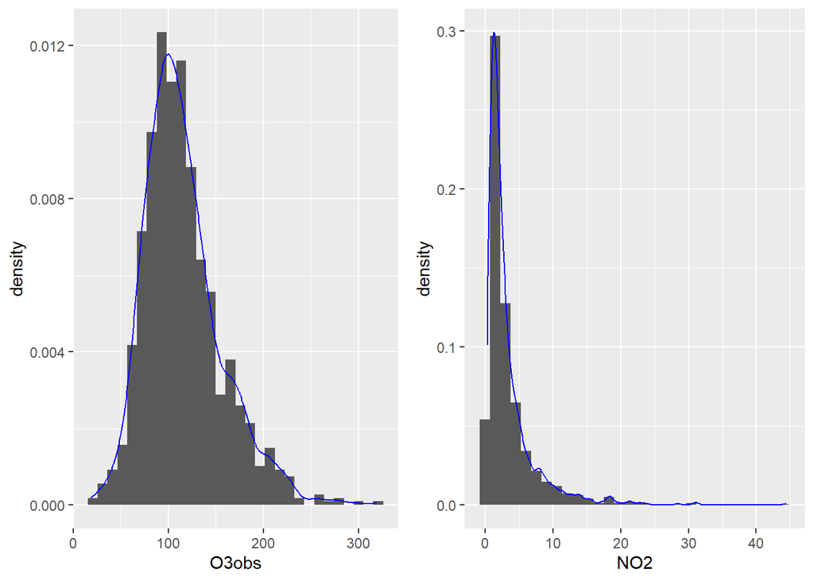

```r
library(ggplot2)
library(gridExtra)
g1<-ggplot(ozone,aes(x=O3obs))+
  geom_histogram(aes(y=after_stat(density)))+
  geom_density(alpha=.2, col="blue")
g2<-ggplot(ozone,aes(x=NO2))+
  geom_histogram(aes(y=..density..))+
  geom_density(alpha=.2, col="blue")

grid.arrange(g1,g2,ncol=2)
```

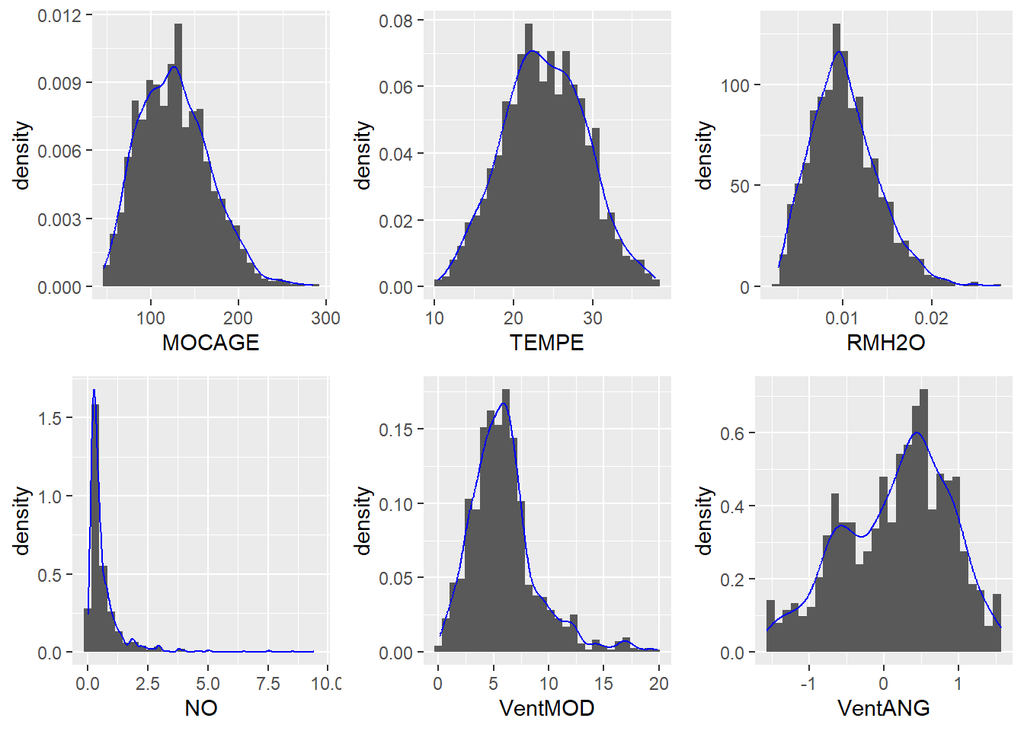

```r
# Même chose pour les autres variables
g3<-ggplot(ozone,aes(x=MOCAGE))+geom_histogram(aes(y=..density..))+geom_density(alpha=.2, col="blue")
g4<-ggplot(ozone,aes(x=TEMPE))+geom_histogram(aes(y=..density..))+geom_density(alpha=.2, col="blue")
g5<-ggplot(ozone,aes(x=RMH2O))+geom_histogram(aes(y=..density..))+geom_density(alpha=.2, col="blue")
g6<-ggplot(ozone,aes(x=NO))+geom_histogram(aes(y=..density..))+geom_density(alpha=.2, col="blue")
g7<-ggplot(ozone,aes(x=VentMOD))+geom_histogram(aes(y=..density..))+geom_density(alpha=.2, col="blue")
g8<-ggplot(ozone,aes(x=VentANG))+geom_histogram(aes(y=..density..))+geom_density(alpha=.2, col="blue")

grid.arrange(g3,g4,g5,g6,g7,g8,ncol=3)
```

```r
rm(g1,g2,g3,g4,g5,g6,g7,g8)
```

### Transformations de variables

Des transformations sont proposées pour rendre certaines distributions plus symétriques et ainsi plus “gaussiennes”. C’est nécessaire pour certaines méthodes à venir de modélisation (linéaires), pas pour toutes (arbres).

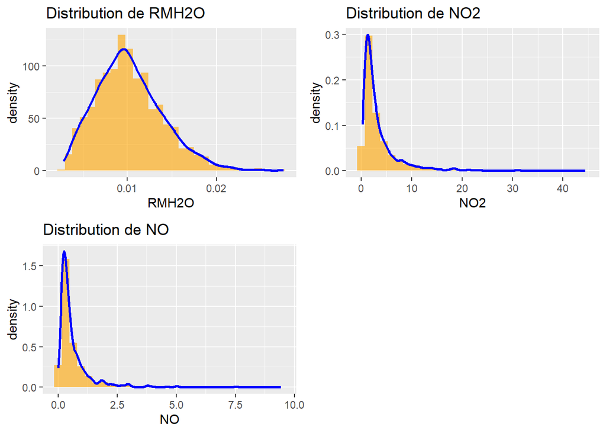

```r
g1 <- ggplot(ozone, aes(x=RMH2O)) +
  geom_histogram(aes(y=..density..), bins=30, fill="orange", alpha=0.6) +
  geom_density(col="blue", linewidth=1) +
  ggtitle("Distribution de RMH2O")


# NO2 vs LNO2 (logarithme)
g3 <- ggplot(ozone, aes(x=NO2)) +
  geom_histogram(aes(y=..density..), bins=30, fill="orange", alpha=0.6) +
  geom_density(col="blue", linewidth=1) +
  ggtitle("Distribution de NO2")



# NO vs LNO (logarithme)
g5 <- ggplot(ozone, aes(x=NO)) +
  geom_histogram(aes(y=..density..), bins=30, fill="orange", alpha=0.6) +
  geom_density(col="blue", linewidth=1) +
  ggtitle("Distribution de NO")


grid.arrange(g1, g3, g5, ncol=2)
```

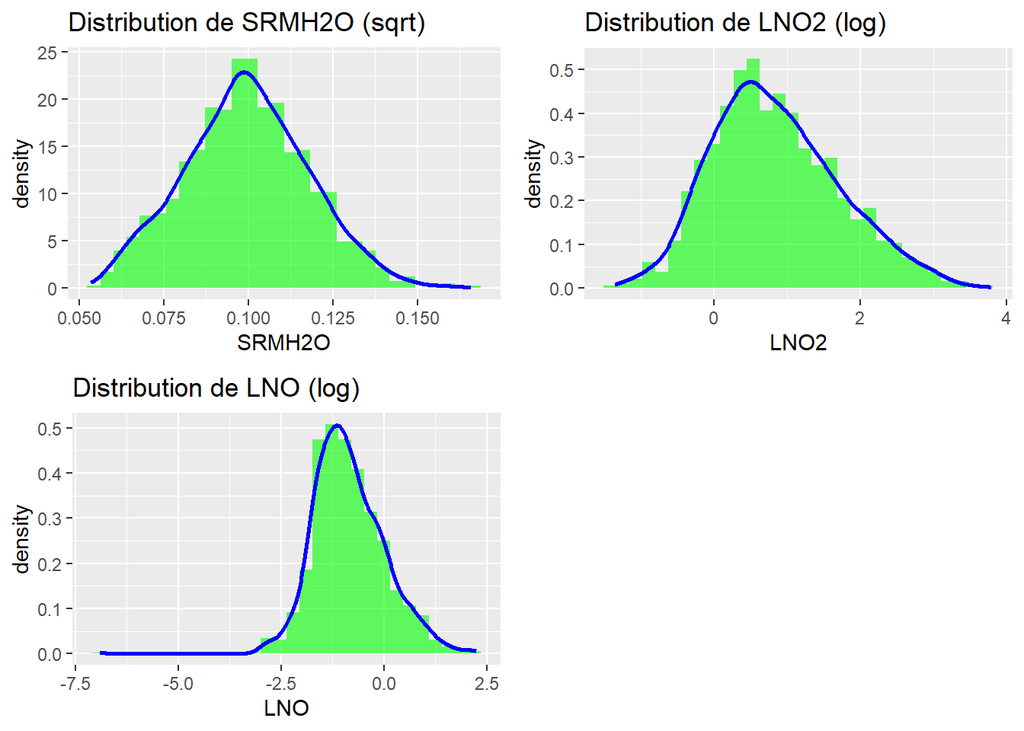

```r
ozone[, "SRMH2O"] <- sqrt(ozone[, "RMH2O"])
ozone[, "LNO2"] <- log(ozone[, "NO2"])
ozone[, "LNO"] <- log(ozone[, "NO"])


g2 <- ggplot(ozone, aes(x=SRMH2O)) +
  geom_histogram(aes(y=..density..), bins=30, fill="green", alpha=0.6) +
  geom_density(col="blue", linewidth=1) +
  ggtitle("Distribution de SRMH2O (sqrt)")

g4 <- ggplot(ozone, aes(x=LNO2)) +
  geom_histogram(aes(y=..density..), bins=30, fill="green", alpha=0.6) +
  geom_density(col="blue", linewidth=1) +
  ggtitle("Distribution de LNO2 (log)")


g6 <- ggplot(ozone, aes(x=LNO)) +
  geom_histogram(aes(y=..density..), bins=30, fill="green", alpha=0.6) +
  geom_density(col="blue", linewidth=1) +
  ggtitle("Distribution de LNO (log)")

grid.arrange(g2, g4, g6, ncol=2)
```

**Question** Vérifiez l’opportunité de ces transformations puis retirez les variables initiales

**Réponse**

- SRMH2O, LNO2 et LNO:

On remarque qu’elles sont devenue plus symetrique et concentrée autour de la moyenne

```r
ozone <- ozone[, c(1:4, 8:13)]
```

On construit maintenant la variable de dépassement de seuil `DepSeuil` pour obtenir le fichier qui sera effectivement utilisé.

```r
ozone[, "DepSeuil"] <- as.factor(ozone[, "O3obs"] > 150)
summary(ozone)
```

```
##  JOUR        O3obs           MOCAGE          TEMPE       STATION
##  0:724   Min.   : 19.0   Min.   : 46.4   Min.   :10.40   Aix:199
##  1:317   1st Qu.: 87.0   1st Qu.: 97.5   1st Qu.:20.20   Als:222
##          Median :109.0   Median :125.6   Median :23.80   Cad:202
##          Mean   :115.4   Mean   :127.2   Mean   :23.88   Pla:208
##          3rd Qu.:135.0   3rd Qu.:153.6   3rd Qu.:27.60   Ram:210
##          Max.   :319.0   Max.   :284.7   Max.   :38.00
##     VentMOD           VentANG            SRMH2O             LNO2
##  Min.   : 0.1414   Min.   :-1.5708   Min.   :0.05339   Min.   :-1.3548
##  1st Qu.: 3.9623   1st Qu.:-0.3948   1st Qu.:0.08735   1st Qu.: 0.2215
##  Median : 5.5973   Median : 0.2783   Median :0.09925   Median : 0.7462
##  Mean   : 5.9072   Mean   : 0.1631   Mean   :0.09957   Mean   : 0.8440
##  3rd Qu.: 7.1063   3rd Qu.: 0.6926   3rd Qu.:0.11153   3rd Qu.: 1.4017
##  Max.   :19.8910   Max.   : 1.5708   Max.   :0.16592   Max.   : 3.7931
##       LNO           DepSeuil
##  Min.   :-6.9078   FALSE:863
##  1st Qu.:-1.4439   TRUE :178
##  Median :-0.9467
##  Mean   :-0.8399
##  3rd Qu.:-0.2957
##  Max.   : 2.2438
```

### Corrélations des variables

**Question** Que dire sur les relations des variables 2 à 2 ?

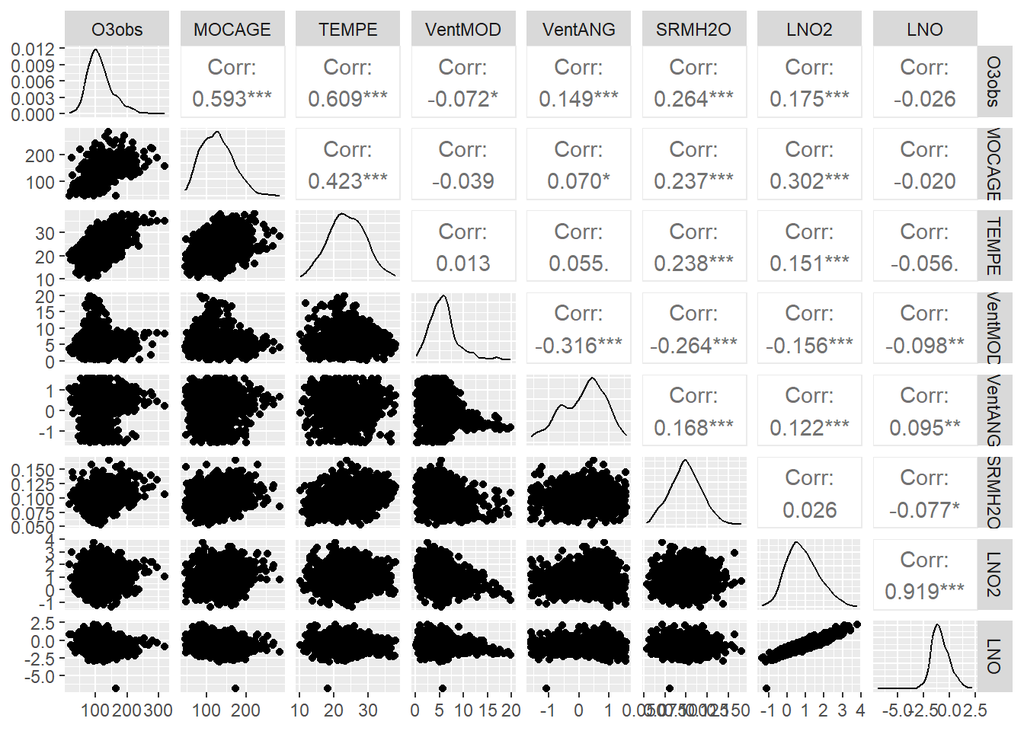

```r
library(GGally)

ggpairs(ozone[, c(2:4, 6:10)])
```

**Réponse**

O3obs et MOCAGE présentent une corrélation modérée à forte (0.593), ce qui pourrait indiquer que le modèle MOCAGE suit de près les observations d’ozone.

**Question** Complétez en visualisant les corrélations avec la fonction `corrplot()` (package `corrplot`). Quelle est la limite de ce type de diagnostic numérique : quel type de corrélation est mesuré ?

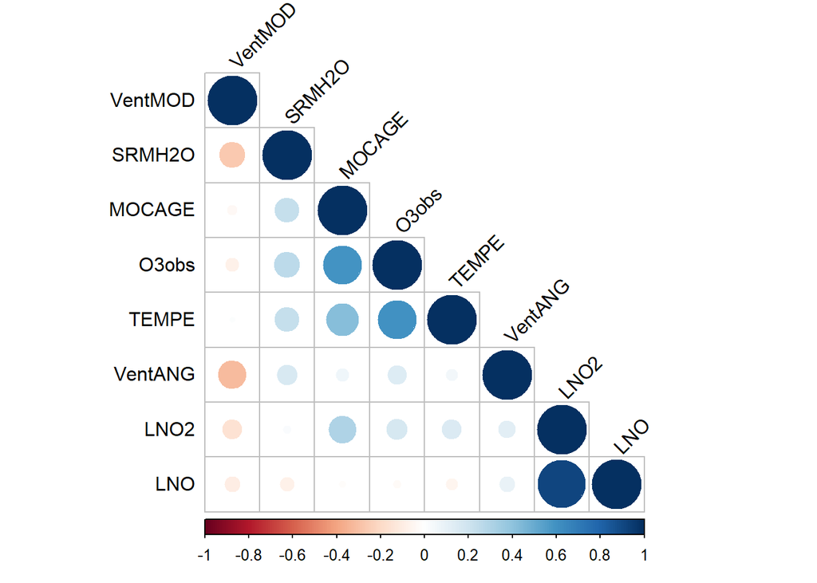

```r
library(corrplot)
corr_matrix <- cor(ozone[, c(2:4, 6:10)], use = "complete.obs")

corrplot(corr_matrix, method = "circle", type = "lower", order = "hclust", tl.col = "black", tl.srt = 45)
```

**Réponse**

La matrice de corrélation affichée utilise probablement la corrélation de Pearson, qui mesure la relation linéaire entre deux variables. La limite de ce type de diagnostic est qu’il ne détecte que les relations linéaires.

### Analyse en composantes principales

Les commandes suivantes permettent de réaliser une [analyse en composantes principales](http://wikistat.fr/pdf/st-m-explo-acp.pdf) (ACP) sur les seules variables quantitatives. Par ailleurs la variable à modéliser (O3obs, concentration observée) n’est pas utilisée.

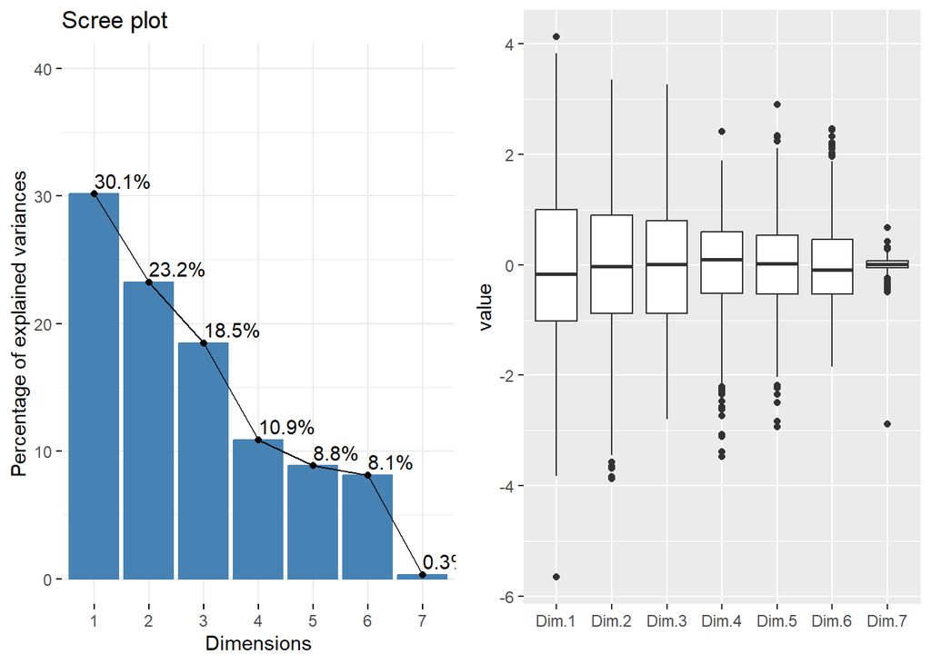

```r
# ACP réduite
library(FactoMineR)
acp <- PCA(ozone[, c(11,2:4, 6:10)], scale.unit = TRUE,
           graph = FALSE, quali.sup = 1, quanti.sup = 2, ncp = 7)
# Décroissance des valeurs propres
library(factoextra)
g1<-fviz_eig(acp, addlabels = TRUE, ylim = c(0, 40))
library(reshape2)
g2<-ggplot(melt(acp$ind$coord),aes(x=Var2,y=value))+
  geom_boxplot()+
  xlab("")
grid.arrange(g1,g2,ncol=2)
```

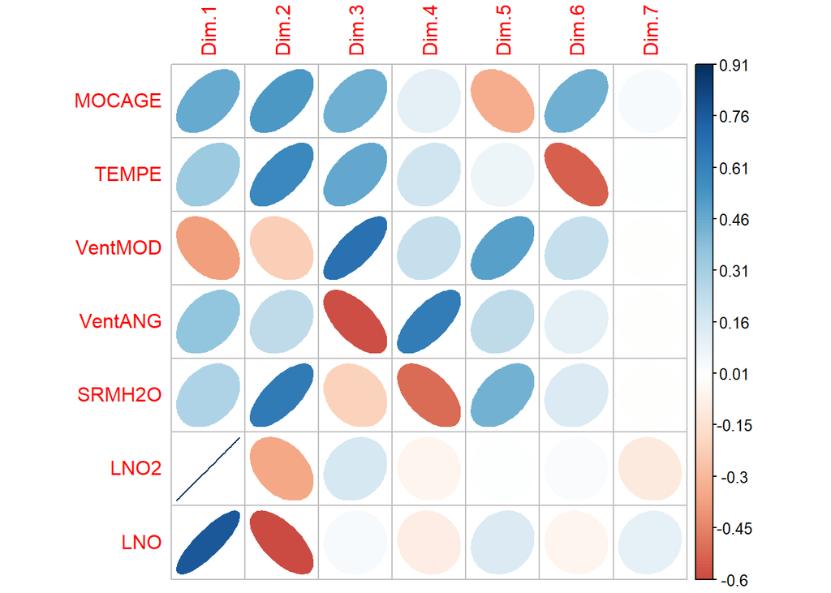

```r
#
library(corrplot)
corrplot(acp$var$cor, is.corr=FALSE,method="ellipse")
```

```r
help(PCA)
```

```
## démarrage du serveur d'aide httpd ... fini
```

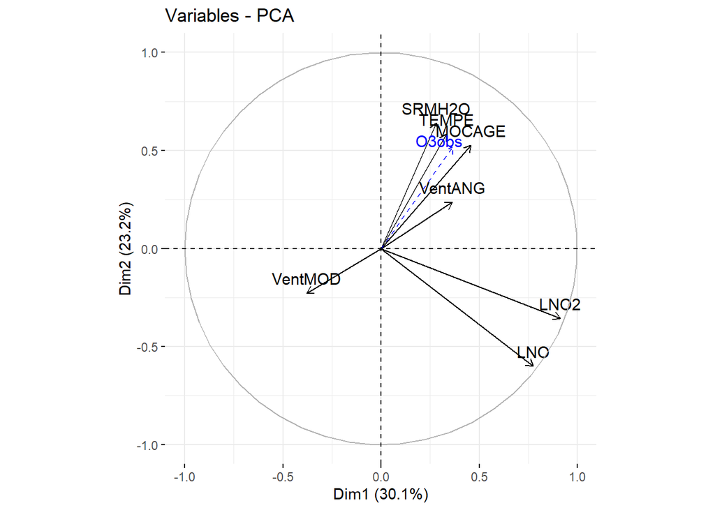

```r
fviz_pca_var(acp)
```

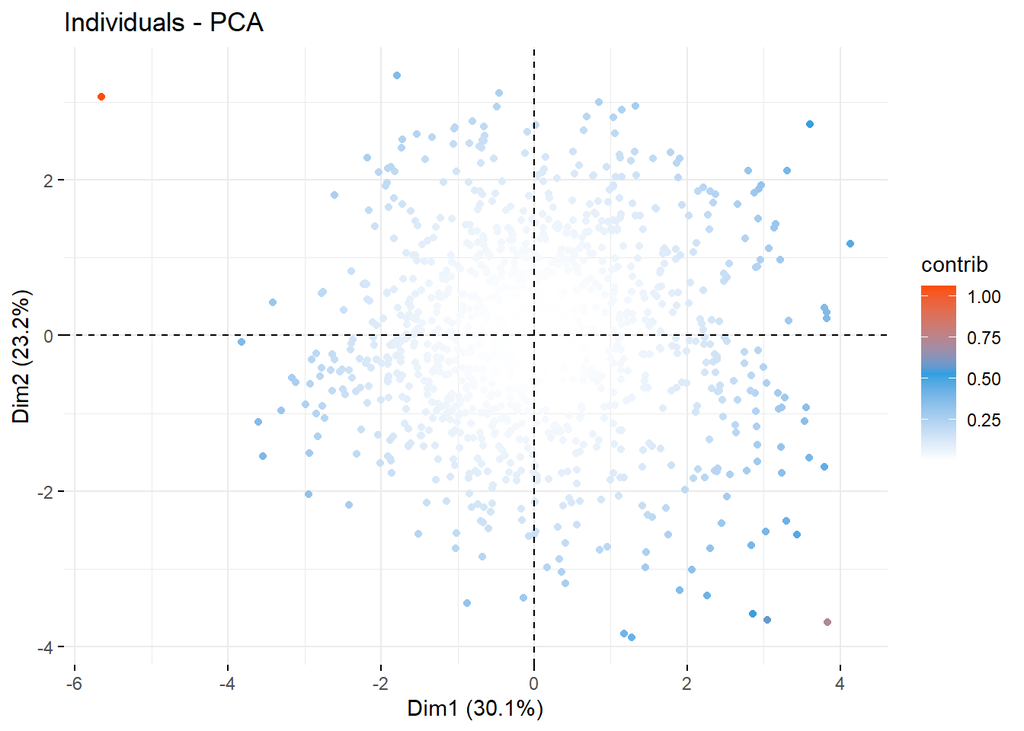

```r
fviz_pca_ind(acp,col.ind="contrib",label="none",gradient.cols = c("white", "#2E9FDF", "#FC4E07" ))
```

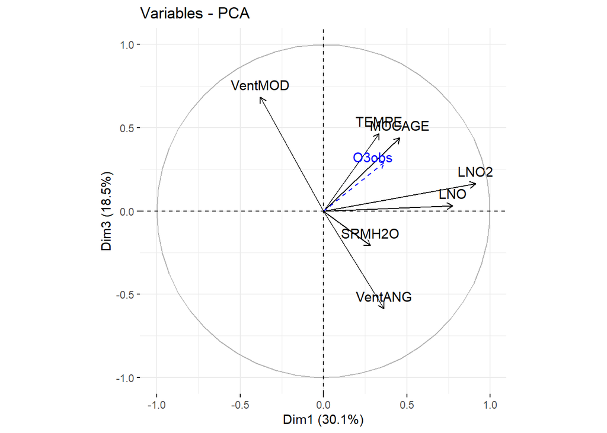

```r
fviz_pca_var(acp,axes=c(1,3))
```

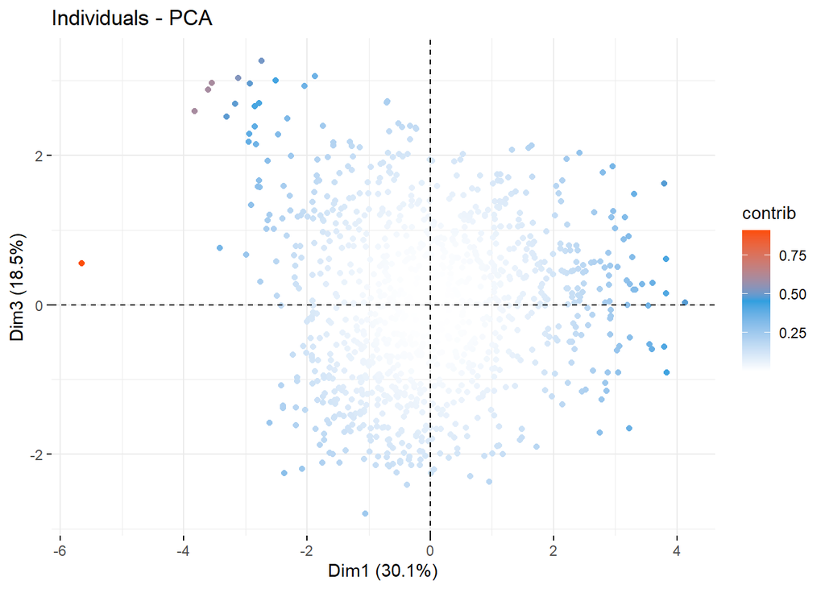

```r
fviz_pca_ind(acp,col.ind="contrib",label="none",gradient.cols = c("white", "#2E9FDF", "#FC4E07" ),axes=c(1,3))
```

**Question** Que représentent ces différents graphiques?

**Réponse**

# La troisième dimension apporte moins d’information et est donc moins importante.

**Question** Que dire du choix du nombre de dimensions, des valeurs atypiques?

**Réponse**

Souvent, les deux premiere dimensions suffissent a expliqué la majorité de la variance.

**Question** Que dire de la structure de corrélation des variables ? Est-elle intuitive ?

**Réponse**

Le graphique de corrélation des variables (fviz_pca_var()) montre comment les variables sont liées entre elles en termes de corrélation. Les flèches orientées dans la même direction ou presque, confirme des corrélations, elle ne semble pas intuitive au premier regard.

Même graphe en coloriant selon le dépassement de seuil.

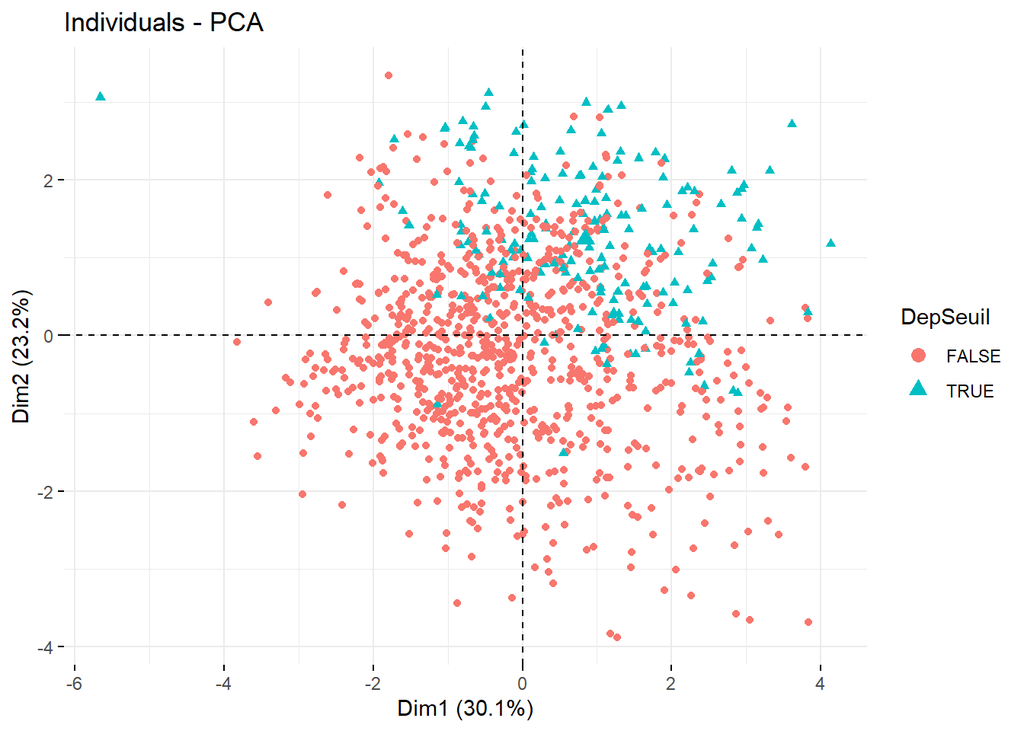

```r
fviz_pca_ind(acp, label="none", habillage=1)
```

L’objectif est donc de définir une surface séparant les deux classes.

**Question** Une discrimination linéaire (hyperplan) semble-t-elle possible ?

**Réponse**

En observant le graphique, il ne semble pas y avoir une séparation nette et claire qui permettrait de définir un hyperplan discriminant linéairement les deux groupes définis par la variable DepSeuil.

### Clustering

Ce n’est pas utile ici mais une classification non supervisée est facile à obtenir. Par exemple en 2 classes, par l’algorithme des K-means. Donne-t-elle la même information ?

**Réponse** La classification non supervisée, comme celle réalisée par l’algorithme K-means, vise à regrouper les données en un certain nombre de clusters basés sur la similarité des caractéristiques. Elle ne fournit pas directement la même information qu’une PCA, car son objectif est de regrouper les individus plutôt que de réduire la dimensionnalité.

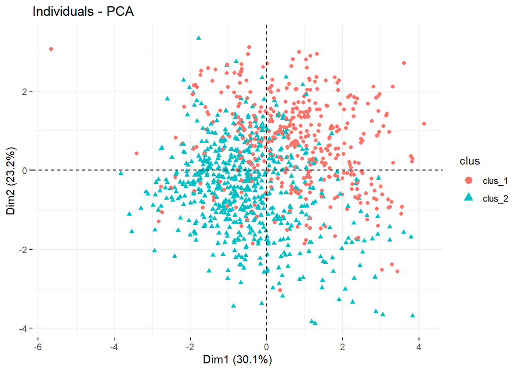

```r
km.ozone <- kmeans(ozone[, c(3:4, 6:10)], centers = 2)
# Représentation dans les coordonnées de l'acp
acp2 <- PCA(cbind(clus = as.factor(km.ozone$cluster),
          ozone[, c(11, 3:4, 6:10)]), scale.unit = TRUE,
          graph = FALSE, quali.sup = 1:2, ncp = 7)
fviz_pca_ind(acp2, label="none", habillage="clus")
```

## Protocole de comparaison

### Stratégie

La recherche d’une meilleure méthode de prévision suit le protocole suivant.

1. Étapes descriptives préliminaires uni- et multidimensionnelle visant à repérer les incohérences, les variables non significatives ou de distribution exotique, les individus non concernés ou atypiques… et à étudier les structures des données. Ce peut être aussi la longue étape de construction de variables, attributs ou *features* spécifiques des données.
2. Procéder à un tirage aléatoire d’un échantillon *test* qui ne sera utilisé que lors de la *dernière étape* de comparaison des méthodes.
3. La partie restante est l’échantillon d’*apprentissage* pour l’estimation des paramètres des modèles.
4. Pour chacune des méthodes, optimiser la complexité des modèles en minimisant une estimation “sans biais” de l’erreur de prévision, par exemple par [*validation croisée*](http://wikistat.fr/pdf/st-m-app-risque-estim.pdf):
   - Variables et interactions à prendre en compte dans la régression linéaire ou logistique;
   - variables et méthode pour l’analyse discriminante;
   - nombre de feuilles dans l’arbre de régression ou de classification;
   - architecture (nombre de neurones, pénalisation) du perceptron;
   - algorithme d’agrégation,
   - noyau et pénalisation des SVMs.
5. Comparaison des qualités de prévision sur la base du taux de mal classés pour le seul échantillon test qui est resté à l’écart de tout effort ou “acharnement” pour l’optimisation des modèles.

### Remarques

- En cas d’échantillon relativement “petit” il est recommandé d’itérer la procédure de découpage apprentissage / test, afin de réduire la variance (moyenne) des estimations des erreurs de prévision.

**Question** Comment appelle-t-on cette procédure spécifique de validation croisée ?

**Réponse**

- *Attention* : ne pas “tricher” en modifiant le modèle obtenu lors de l’étape précédente afin d’améliorer le résultat sur l’échantillon test!
- Le critère utilisé dépend du problème : erreur quadratique, taux de mauvais classement, entropie, AUC (aire sous la courbe ROC), indice de Pierce, *log loss function*…

### Extraction des échantillons

Les commandes ci-dessous réalisent l’extraction du sous-ensemble des données d’apprentissage et de test.

Utilisez trois chiffres au hasard, et **remplacez** “111” ci-dessous, comme initialisation du générateur de nombres aléatoires. Attention, chaque participant tire un échantillon différent ; il est donc “normal” de ne pas obtenir les mêmes modèles, les mêmes résultats!

```r
set.seed(111) # initialisation du générateur
# Extraction des échantillons
test.ratio <- .2   # part de l'échantillon test
npop <- nrow(ozone) # nombre de lignes dans les données
nvar <- ncol(ozone) # nombre de colonnes
# taille de l'échantillon test
ntest <- ceiling(npop * test.ratio)
# indices de l'échantillon test
testi <- sample(1:npop, ntest)
# indices de l'échantillon d'apprentissage
appri <- setdiff(1:npop, testi)
```

Construction des échantillons pour la régression: prévision de la concentration en ozone.

```r
# construction de l'échantillon d'apprentissage
datappr <- ozone[appri, -11]
# construction de l'échantillon test
datestr <- ozone[testi, -11]
# vérification
str(datappr)
```

```
## 'data.frame':    832 obs. of  10 variables:
##  $ JOUR   : Factor w/ 2 levels "0","1": 2 2 1 1 1 1 1 2 2 1 ...
##  $ O3obs  : int  91 100 82 94 107 150 164 135 121 129 ...
##  $ MOCAGE : num  93.2 104.6 103.6 94.8 99 ...
##  $ TEMPE  : num  21.5 20.2 17.4 18.8 23.7 23.6 26.6 23.5 23.3 23.7 ...
##  $ STATION: Factor w/ 5 levels "Aix","Als","Cad",..: 1 1 1 1 1 1 1 1 1 1 ...
##  $ VentMOD: num  9.5 8.01 9.38 9.46 7.88 ...
##  $ VentANG: num  -0.643 -0.05 -0.128 -0.345 -0.418 ...
##  $ SRMH2O : num  0.092 0.0939 0.0975 0.0925 0.0855 ...
##  $ LNO2   : num  0.471 0.752 0.505 0.854 0.503 ...
##  $ LNO    : num  -0.858 -0.633 -0.761 -0.355 -0.794 ...
```

```r
str(datestr)
```

```
## 'data.frame':    209 obs. of  10 variables:
##  $ JOUR   : Factor w/ 2 levels "0","1": 1 1 1 2 1 1 1 2 2 2 ...
##  $ O3obs  : int  135 143 71 77 79 155 101 75 114 156 ...
##  $ MOCAGE : num  127.8 189.7 103.9 73 87.8 ...
##  $ TEMPE  : num  18.8 21 25.9 23.5 12.3 32.2 19.4 27.6 24.9 27 ...
##  $ STATION: Factor w/ 5 levels "Aix","Als","Cad",..: 3 4 1 5 5 1 2 3 4 2 ...
##  $ VentMOD: num  2.1 3.14 10.68 4.3 4.6 ...
##  $ VentANG: num  -0.0476 0.6499 -0.7523 0.0232 -0.77 ...
##  $ SRMH2O : num  0.0865 0.1155 0.068 0.0782 0.0906 ...
##  $ LNO2   : num  0.331 -0.456 1.043 0.178 1.028 ...
##  $ LNO    : num  -1.411 -2.551 -0.428 -1.238 -0.272 ...
```

```r
#summary(datappr)
```

Construction des échantillons pour la discrimination: prévision de dépassement.

```r
# construction de l'échantillon d'apprentissage
datappq <- ozone[appri,-2]
# construction de l'échantillon test
datestq <- ozone[testi,-2]

# vérification
str(datappq)
```

```
## 'data.frame':    832 obs. of  10 variables:
##  $ JOUR    : Factor w/ 2 levels "0","1": 2 2 1 1 1 1 1 2 2 1 ...
##  $ MOCAGE  : num  93.2 104.6 103.6 94.8 99 ...
##  $ TEMPE   : num  21.5 20.2 17.4 18.8 23.7 23.6 26.6 23.5 23.3 23.7 ...
##  $ STATION : Factor w/ 5 levels "Aix","Als","Cad",..: 1 1 1 1 1 1 1 1 1 1 ...
##  $ VentMOD : num  9.5 8.01 9.38 9.46 7.88 ...
##  $ VentANG : num  -0.643 -0.05 -0.128 -0.345 -0.418 ...
##  $ SRMH2O  : num  0.092 0.0939 0.0975 0.0925 0.0855 ...
##  $ LNO2    : num  0.471 0.752 0.505 0.854 0.503 ...
##  $ LNO     : num  -0.858 -0.633 -0.761 -0.355 -0.794 ...
##  $ DepSeuil: Factor w/ 2 levels "FALSE","TRUE": 1 1 1 1 1 1 2 1 1 1 ...
```

```r
str(datestq)
```

```
## 'data.frame':    209 obs. of  10 variables:
##  $ JOUR    : Factor w/ 2 levels "0","1": 1 1 1 2 1 1 1 2 2 2 ...
##  $ MOCAGE  : num  127.8 189.7 103.9 73 87.8 ...
##  $ TEMPE   : num  18.8 21 25.9 23.5 12.3 32.2 19.4 27.6 24.9 27 ...
##  $ STATION : Factor w/ 5 levels "Aix","Als","Cad",..: 3 4 1 5 5 1 2 3 4 2 ...
##  $ VentMOD : num  2.1 3.14 10.68 4.3 4.6 ...
##  $ VentANG : num  -0.0476 0.6499 -0.7523 0.0232 -0.77 ...
##  $ SRMH2O  : num  0.0865 0.1155 0.068 0.0782 0.0906 ...
##  $ LNO2    : num  0.331 -0.456 1.043 0.178 1.028 ...
##  $ LNO     : num  -1.411 -2.551 -0.428 -1.238 -0.272 ...
##  $ DepSeuil: Factor w/ 2 levels "FALSE","TRUE": 1 1 1 1 1 2 1 1 1 2 ...
```

```r
#summary(datappq)
```

**Remarque** : Nous avons ici “manuellement” fait la construction des échantillons à des fins pédagogiques. En pratique, on peut utiliser des fonctions de R qui font ce travail, en particulier la fonction `createDataPartition` de la librairie `caret`.

Enfin, avant de passer aux différents algorithmes, définissons une fonction traçant le graphe des résidus avec des couleurs et des échelles fixes sur les axes.

```r
gplot.res <- function(x, y, titre = "titre"){
    ggplot(data.frame(x=x, y=y),aes(x,y))+
    geom_point(col = "blue")+xlim(0, 250)+ylim(-150, 150)+
    ylab("Résidus")+ xlab("Valeurs prédites")+
    ggtitle(titre)+
    geom_hline(yintercept = 0,col="green")
}
```

## [Prévision par modèle linéaire Gaussien](http://wikistat.fr/pdf/st-m-app-select.pdf)

Le premier modèle à tester est un simple modèle linéaire Gaussien mais, comme certaines variables sont qualitatives, il s’agit d’une analyse de covariance. D’autre part, on s’intéresse à savoir si des interactions sont à prendre en compte. Le modèle devient alors polynomial d’ordre 2 ou quadratique.

### Modèle linéaire

#### Sans sélection de variables

Le modèle linéaire intégre ici des variables qualitatives; c’est dans ce cas une *analyse de covariance* estimée par la fonction `aov` mieux adaptée à ce modèle.

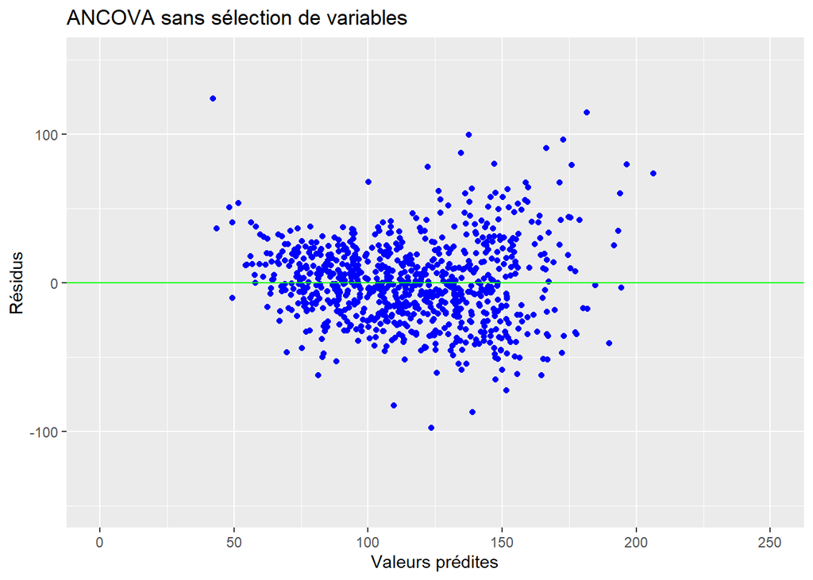

```r
# estimation du modèle sans interaction
reg.lm <-aov(O3obs ~ . , data = datappr)
# Extraction des résidus et des valeurs ajustées de ce modèle
res.lm <- reg.lm$residuals
fit.lm <- reg.lm$fitted.values
# Graphe des résidus.
gplot.res(fit.lm,res.lm,"ANCOVA sans sélection de variables")
```

**Question** Que dire de la distribution de ces résidus ?

**Réponse**

La distribution des résidus semble aléatoire, ce qui est bon, mais il y a des signes d’une dispersion croissante des résidus avec des valeurs prédites plus élevées et quelques résidus extrêmes qui pourraient être des valeurs aberrantes. Cela pourrait indiquer que le modèle de régression pourrait être amélioré.

**Question** La forme du nuage renseigne sur les hypothèses de linéarité du modèle et d’homoscédasticité. Que dire de la validité de ce modèle ?

**Réponse**

Le nuage des résidus montre des signes d’hétéroscédasticité, car la dispersion des résidus augmente avec les valeurs prédites, ce qui viole l’hypothèse d’homoscédasticité.

Appréciez néanmoins sa significativité par la commande suivante.

```r
summary(reg.lm)
```

```
##              Df Sum Sq Mean Sq F value   Pr(>F)
## JOUR          1    106     106   0.134 0.714791
## MOCAGE        1 470173  470173 590.680  < 2e-16 ***
## TEMPE         1 225427  225427 283.204  < 2e-16 ***
## STATION       4  10163    2541   3.192 0.012926 *
## VentMOD       1  13846   13846  17.395 3.36e-05 ***
## VentANG       1  10088   10088  12.673 0.000392 ***
## SRMH2O        1    273     273   0.343 0.558101
## LNO2          1   3337    3337   4.193 0.040918 *
## LNO           1   9006    9006  11.314 0.000805 ***
## Residuals   819 651913     796
## ---
## Signif. codes:  0 '***' 0.001 '**' 0.01 '*' 0.05 '.' 0.1 ' ' 1
```

```r
coef(reg.lm)
```

```
## (Intercept)       JOUR1      MOCAGE       TEMPE  STATIONAls  STATIONCad
## -16.0273451   1.2144463   0.3849814   4.3270454   2.1425958   8.8115799
##  STATIONPla  STATIONRam     VentMOD     VentANG      SRMH2O        LNO2
##  21.0287164   3.4628151  -1.3756918   4.5070677  52.5682991 -14.2991137
##         LNO
##  16.9322029
```

**Question** Ce premier modèle est comparé avec celui de la seule prévision déterministe MOCAGE. Qu’en conclure?

**Réponse**

Dans le tableau, plusieurs facteurs sont listés (comme JOUR, MOCAGE, TEMPE, etc.), avec leurs valeurs statistiques respectives. Les astérisques (***, **, *) indiquent le niveau de signification statistique, avec plus d’astérisques indiquant des preuves plus fortes contre l’hypothèse nulle. Par exemple, “MOCAGE” et “TEMPE” ont des valeurs p très basses (indiquées par < 2e-16 ***), suggérant que leurs effets sont statistiquement significatifs.

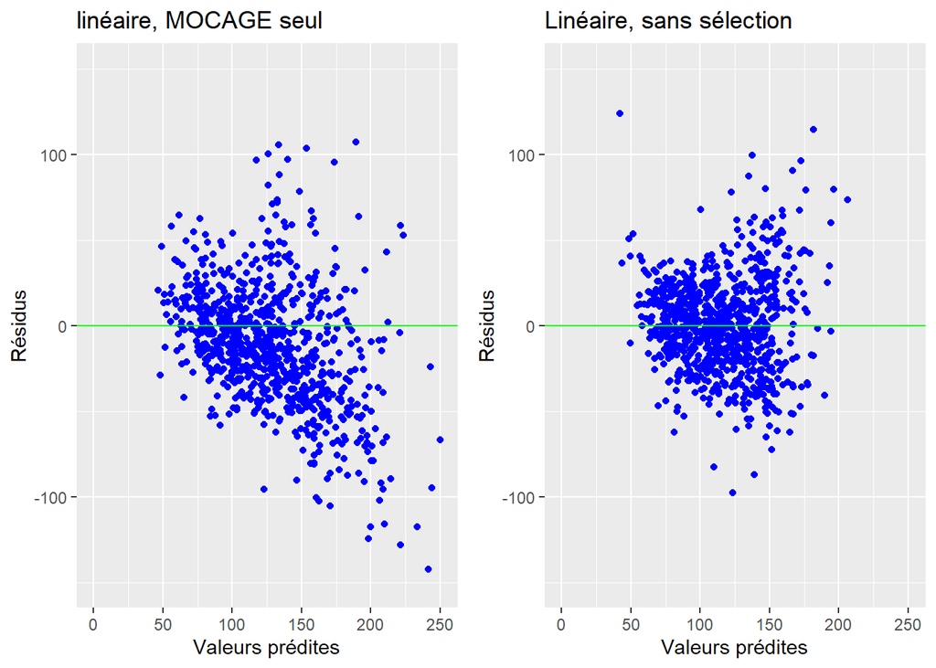

```r
# Graphe des résidus du modèle déterministe MOCAGE
g1<-gplot.res(datappr[, "MOCAGE"],datappr[, "O3obs"]-datappr[, "MOCAGE"], "linéaire, MOCAGE seul")

g2<-gplot.res(fit.lm, res.lm, "Linéaire, sans sélection")
grid.arrange(g1,g2,ncol=2)
```

#### Sélection de variable par régularisation L1 (LASSO)

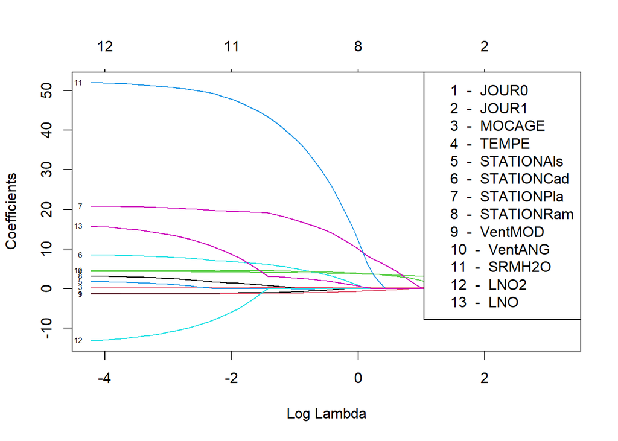

```r
library(glmnet)
# avec des variables quantitatives seulement
reg.lasso.quanti <- glmnet(y = datappr[, 2],
                           x = as.matrix(datappr[, -c(1, 2, 5)]))
# avec toutes les variables, créer d'abord la matrice d'expériences
# avec 'model.matrix' (penser à retirer l'intercept du modèle)
x.mat <- model.matrix(O3obs ~ . - 1, data = datappr)
reg.lasso <- glmnet(y = datappr$O3obs, x = x.mat)
options(repr.plot.width = 12, repr.plot.height = 10)
plot(reg.lasso, xvar = "lambda", label = TRUE)
legend("topright",
       legend = paste(1:ncol(x.mat), " - ", colnames(x.mat)))
```

**Question** Que fait la commande model.matrix ? Comment sont gérées les variables catégorielles ?

**Réponse**

Elle permet de créer une matrice , cette matrice est composée de variables indépendantes sous forme numérique, prêtes à être utilisées pour l’analyse statistique ou la modélisation. Elle gère automatiquement la conversion des variables catégorielles en en variables muettes.

```r
#help(model.matrix)
head(x.mat)
```

```
##   JOUR0 JOUR1 MOCAGE TEMPE STATIONAls STATIONCad STATIONPla STATIONRam VentMOD
## 1     0     1   93.2  21.5          0          0          0          0  9.5000
## 2     0     1  104.6  20.2          0          0          0          0  8.0100
## 3     1     0  103.6  17.4          0          0          0          0  9.3771
## 4     1     0   94.8  18.8          0          0          0          0  9.4578
## 5     1     0   99.0  23.7          0          0          0          0  7.8791
## 6     1     0  114.3  23.6          0          0          0          0  6.3127
##    VentANG     SRMH2O      LNO2        LNO
## 1 -0.64350 0.09203260 0.4712528 -0.8580218
## 2 -0.04996 0.09386160 0.7518877 -0.6329933
## 3 -0.12832 0.09751923 0.5050087 -0.7614260
## 4 -0.34516 0.09246621 0.8544153 -0.3552474
## 5 -0.41822 0.08549854 0.5025918 -0.7940731
## 6  0.06341 0.10871982 1.6707211  0.2949059
```

**Question** Que représentent les courbes ci-dessus, appelées “chemins de régularisation”?

**Réponse**

On s’intéresse ensuite au choix du paramètre de régularisation par validation croisée:

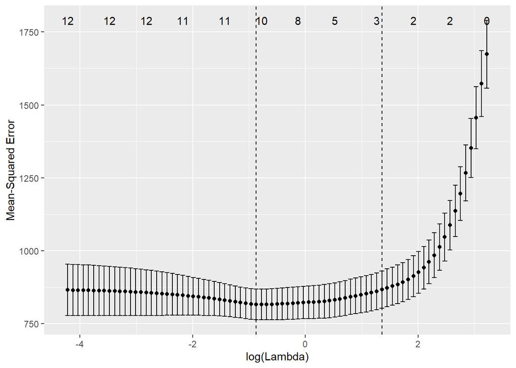

```r
reg.lasso.cv <- cv.glmnet(y = datappr[, 2], x = x.mat)
#plot(reg.lasso.cv)
autoplot(reg.lasso.cv)
```

```r
library(glmnet)
help(cv.glmnet)
```

**Question** Que représente les points gras ? Et la bande qui est autour ?

**Réponse**

Les points gras représentent généralement la moyenne de l’erreur de validation croisée pour chaque valeur de lambda et la bande autour des points gras représente l’intervalle de confiance ou l’écart-type de l’erreur de validation croisée pour chaque valeur de lambda. Cela donne une idée de la variabilité ou de l’incertitude de l’estimation de l’erreur pour chaque modèle. Un intervalle plus large suggère une plus grande incertitude et vice versa.

**Réponse** - Génération de Valeurs de lambda :

Lors de l’ajustement du modèle LASSO avec la fonction glmnet, une séquence de valeurs de lambda est générée. Ces valeurs déterminent le degré de régularisation appliqué au modèle.

- Validation Croisée :

Avec cv.glmnet, une validation croisée est effectuée sur ces différentes valeurs de lambda. Pour chaque valeur de lambda testée, le modèle est ajusté, et l’erreur de validation croisée est calculée.

- Calcul de l’Erreur de Validation :

Pour chaque valeur de lambda, l’erreur moyenne de validation croisée est calculée. Cela produit une courbe d’erreur en fonction des valeurs de lambda.

- Identification de lambda.min et lambda.1se :

lambda.min : C’est la valeur de lambda qui minimise l’erreur de validation croisée. Elle est souvent marquée par une ligne verticale en pointillé dans le graphique.

lambda.1se : C’est la plus grande valeur de lambda qui se situe à une unité d’écart-type au-dessus de l’erreur minimale (obtenue pour lambda.min). Cela permet d’obtenir un modèle plus simple tout en conservant une performance raisonnable.

Ces deux valeurs sont automatiquement calculées par la fonction cv.glmnet.

- Conversion en log(lambda) :

Étant donné que le graphique utilise l’échelle logarithmique pour lambda, les valeurs de lambda correspondantes à lambda.min et lambda.1se sont converties en log(lambda).

```r
# valeur estimée
paste("CV estimate of lambda :", round(reg.lasso.cv$lambda.1se, 3))
```

```
## [1] "CV estimate of lambda : 3.896"
```

```r
# modèle correspondant
coef(reg.lasso.cv, s = "lambda.1se")
```

```
## 14 x 1 sparse Matrix of class "dgCMatrix"
##                    s1
## (Intercept) 1.1658431
## JOUR0       .
## JOUR1       .
## MOCAGE      0.3370194
## TEMPE       2.9855716
## STATIONAls  .
## STATIONCad  .
## STATIONPla  .
## STATIONRam  .
## VentMOD     .
## VentANG     0.4939697
## SRMH2O      .
## LNO2        .
## LNO         .
```

**Question** Combien restent-ils de coefficients non nuls. Vérifiez sur les chemins de régularisation.

Il y’a trois coefficients non nuls MOCAGE, TEMPE et VentANG.

**Question** Même question en choisissant l’autre valeur de lambda retenue par glmnet, i.e. `reg.lasso.cv$lambda.min`

```r
coef_non_nuls_min <- sum(coef(reg.lasso.cv, s = "lambda.min") != 0) - 1
print(paste("Nombre de coefficients non nuls avec lambda.min :", coef_non_nuls_min))
```

```
## [1] "Nombre de coefficients non nuls avec lambda.min : 10"
```

**Réponse**

Nous obtenons 10 coefficients non nuls.

```r
# valeur estimée
paste("CV estimate of lambda :", round(reg.lasso.cv$lambda.min, 3))
```

```
## [1] "CV estimate of lambda : 0.418"
```

```r
# modèle correspondant
coef(reg.lasso.cv, s = "lambda.min")
```

```
## 14 x 1 sparse Matrix of class "dgCMatrix"
##                       s1
## (Intercept) -18.02986736
## JOUR0        -0.67101204
## JOUR1         .
## MOCAGE        0.29912279
## TEMPE         4.00531665
## STATIONAls   -0.09333231
## STATIONCad    4.71348395
## STATIONPla   16.73098026
## STATIONRam    .
## VentMOD      -1.06568750
## VentANG       4.32796699
## SRMH2O       35.78513984
## LNO2          .
## LNO           2.55034443
```

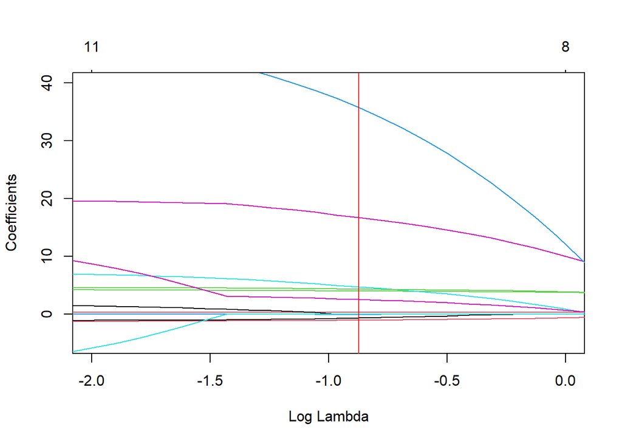

```r
plot(reg.lasso, xvar = "lambda", label = TRUE,xlim=c(-2,0),ylim=c(-5,40))
abline(v=log(reg.lasso.cv$lambda.min),col="red")
```

On trace ensuite les résidus en fonction des valeurs prédites.

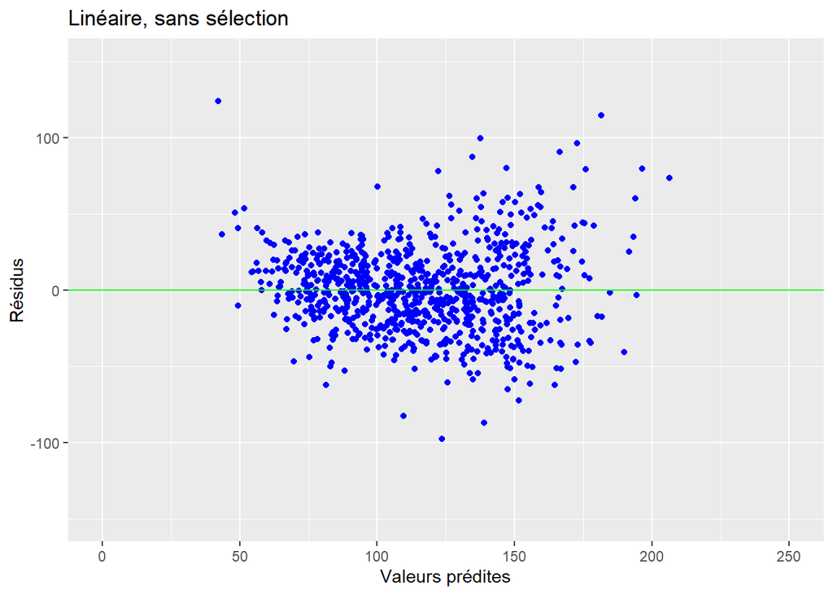

```r
# Extraction des valeurs ajustées et des résidus

fit.lasso <- predict(reg.lasso.cv, s = "lambda.min", newx = x.mat)
res.lasso <- datappr$O3obs - fit.lasso

fit.lasso.1se <- predict(reg.lasso.cv, s = "lambda.1se", newx = x.mat)
res.lasso.1se <- datappr$O3obs - fit.lasso.1se

# Graphe des résidus
options(repr.plot.width = 12, repr.plot.height = 4)
par(mfrow = c(1, 3))
gplot.res(fit.lm, res.lm, "Linéaire, sans sélection")
```

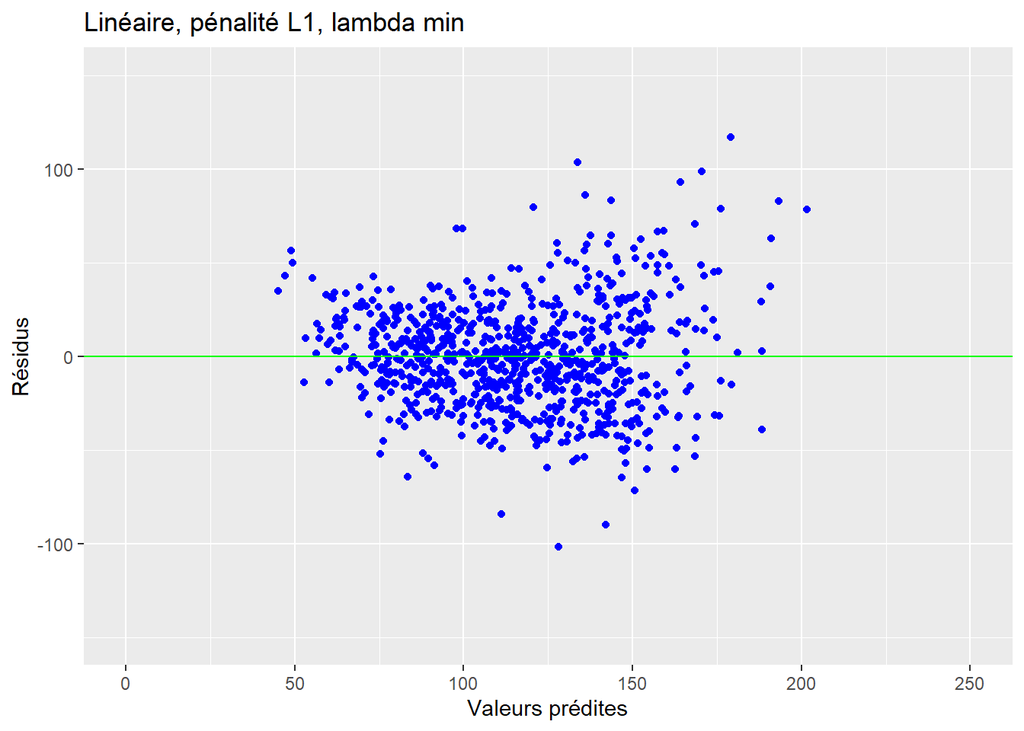

```r
gplot.res(fit.lasso, res.lasso, "Linéaire, pénalité L1, lambda min")
```

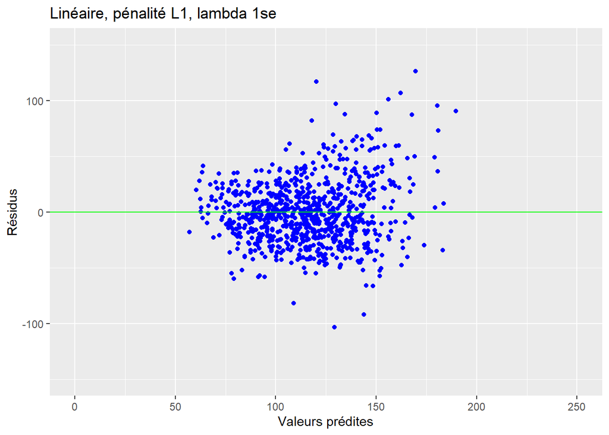

```r
gplot.res(fit.lasso.1se, res.lasso.1se, "Linéaire, pénalité L1, lambda 1se")
```

**Question** Commentez.

**Réponse**

- Graphique Linéaire, sans sélection

Les points des résidus sont dispersés autour de la ligne horizontale à zéro. Cela peut indiquer que le modèle linéaire sans sélection a capturé une certaine relation entre les variables, mais il peut également montrer une variabilité dans les erreurs, ce qui suggère qu’il y a encore des aspects des données que le modèle n’a pas bien saisis. Il y’a une Hétéroscédasticité.

- Graphique Linéaire, pénalité L1, lambda.min

Les résidus sont assez similaires à ceux du modèle linéaire sans sélection. Cependant, on peut voir une légère amélioration dans la structure des résidus, car le Lasso tend à réduire l’impact des variables moins importantes.

- Graphique Linéaire, pénalité L1, lambda.1se

**Question** Calculez le critère MSE (moyenne des carrés des résidus) pour les deux modèles. Pourquoi celui obtenu par LASSO est-il moins bon ? Quel critère LASSO minimise t-il ?

**Réponse** Le LASSO se concentre sur la minimisation du MSE tout en ajoutant une pénalité pour la complexité du modèle, le modèle LASSO n’inclut pas suffisamment d’informations pertinentes.

```r
paste("Modèle linéaire sans sélection:",mean(res.lm^2))
```

```
## [1] "Modèle linéaire sans sélection: 783.549239590938"
```

```r
paste("LASSO avec lambda.min:",mean(res.lasso^2))
```

```
## [1] "LASSO avec lambda.min: 793.58476401389"
```

```r
paste("LASSO avec lambda.1se:",mean(res.lasso.1se^2))
```

```
## [1] "LASSO avec lambda.1se: 859.648320971249"
```

**Question** Estimez l’erreur du modèle linéaire simple sans sélection de variables par validation croisée. Comparez avec celle du LASSO. Qu’observez-vous?

```r
V=10 ; nV=floor(nrow(datappr)/V)
S=sample(1:nrow(datappr),replace=FALSE)
error.CV = c()
for(v in 1:V)
{ # Rq : les deux dernières obs sont tjs dans l'échantillon d'apprentissage...
    datappr.learn=datappr[-c(S[(nV*(v-1)):(nV*v)]),]
    datappr.valid=datappr[c(S[(nV*(v-1)):(nV*v)]),]
    error.CV=c(error.CV,mean((datappr.valid$O3obs-predict(aov(O3obs ~ ., data=datappr.learn),newdata=datappr.valid))^2))
}
mean(error.CV)
```

```
## [1] 865.6682
```

```r
print(reg.lasso.cv)
```

```
##
## Call:  cv.glmnet(x = x.mat, y = datappr[, 2])
##
## Measure: Mean-Squared Error
##
##     Lambda Index Measure    SE Nonzero
## min  0.418    45   815.9 52.58      10
## 1se  3.896    21   867.0 64.04       3
```

```r
V = 10
nV = floor(nrow(datappr) / V)
S = sample(1:nrow(datappr), replace = FALSE)
error.CV = c()

for (v in 1:V) {
  # Définition des jeux d'apprentissage et de validation pour chaque pli
  datappr.learn = datappr[-c(S[(nV * (v - 1)):(nV * v)]), ]
  datappr.valid = datappr[c(S[(nV * (v - 1)):(nV * v)]), ]

  # Ajustement du modèle linéaire sans sélection de variables
  model.lm = aov(O3obs ~ ., data = datappr.learn)

  # Calcul des prédictions sur le jeu de validation
  predictions = predict(model.lm, newdata = datappr.valid)

  # Calcul de l'erreur quadratique moyenne pour ce pli
  mse_fold = mean((datappr.valid$O3obs - predictions) ^ 2)

  # Ajout de l'erreur du pli à la liste d'erreurs
  error.CV = c(error.CV, mse_fold)
}

# Erreur moyenne sur les 10 plis
mean.error.lm = mean(error.CV)
mean.error.lm
```

```
## [1] 858.7197
```

**Réponse**

LASSO minimise le MSE tout en appliquant une pénalisation, ce qui permet de sélectionner les variables les plus importantes. Le modèle LASSO avec lambda.min donne de meilleurs résultats (en termes de MSE) que le modèle linéaire sans sélection. LASSO minimise donc le compromis entre biais et variance et favorise des modèles plus simples tout en conservant une bonne précision.

### Modèle quadratique

L’étude suivante met en oeuvre toutes les interactions d’ordre 2 entre les variables. Il s’agit donc d’un modèle de régression quadratique. Il est estimé avec la fonction `glm()` qui permet une sélection automatique de modèle. La méthode descendante est utilisée mais celle pas-à-pas pourrait également l’être. Ce type de procédure n’est pas implémentée en python.

#### Sélection de variables par critère AIC

Sélection descendante: à chaque étape, chaque modèle est comparé à tous les sous-modèles possibles obtenus par suppression d’une des interactions ou une des variables, à condition qu’elle ne soit pas présente dans une interaction. La variable sélectionnée et supprimée est celle qui fait décroîre le critère considéré : AIC (*Akaïke Information Criterion*).

**Question** Quel autre critère, équivalent à AIC dans le cas gaussien et de variance résiduelle connue, est utilisé en régression linéaire ?

**Réponse**

En régression linéaire, lorsque la variance résiduelle est connue et que le modèle est gaussien, le critère de sélection de modèle équivalent à l’AIC est le Critère d’Information de Bayes, ou BIC

```r
# Estimation du modèle avec toutes les interactions d'ordre 2
reg.glm <- glm(O3obs ~ .^2, data = datappr)
# Recherche du meilleur modèle au sens
# du critère d'Akaïke par méthode descendante
reg.glm.step <- step(reg.glm, direction = "backward")
```

```
## Start:  AIC=7783.44
## O3obs ~ (JOUR + MOCAGE + TEMPE + STATION + VentMOD + VentANG +
##     SRMH2O + LNO2 + LNO)^2
##
##                   Df Deviance    AIC
## - JOUR:STATION     4   471877 7776.5
## - STATION:VentANG  4   471970 7776.7
## - JOUR:TEMPE       1   471262 7781.4
## - JOUR:LNO2        1   471262 7781.4
## - LNO2:LNO         1   471263 7781.4
## - JOUR:SRMH2O      1   471265 7781.4
## - MOCAGE:TEMPE     1   471270 7781.5
## - JOUR:LNO         1   471321 7781.5
## - JOUR:MOCAGE      1   471324 7781.6
## - VentMOD:VentANG  1   471374 7781.6
## - JOUR:VentANG     1   471464 7781.8
## - MOCAGE:VentANG   1   471510 7781.9
## - MOCAGE:STATION   4   475115 7782.2
## - JOUR:VentMOD     1   471774 7782.3
## - VentANG:SRMH2O   1   471804 7782.4
## - MOCAGE:SRMH2O    1   471846 7782.5
## - VentMOD:LNO2     1   472012 7782.8
## - TEMPE:VentMOD    1   472318 7783.3
## <none>                 471261 7783.4
## - VentMOD:LNO      1   472416 7783.5
## - MOCAGE:VentMOD   1   472452 7783.5
## - STATION:LNO      4   476488 7784.6
## - VentANG:LNO2     1   473094 7784.7
## - VentMOD:SRMH2O   1   473263 7785.0
## - TEMPE:VentANG    1   473577 7785.5
## - SRMH2O:LNO2      1   473719 7785.8
## - SRMH2O:LNO       1   473881 7786.1
## - MOCAGE:LNO       1   474066 7786.4
## - VentANG:LNO      1   474390 7786.9
## - STATION:VentMOD  4   477962 7787.2
## - STATION:LNO2     4   478328 7787.8
## - MOCAGE:LNO2      1   475109 7788.2
## - TEMPE:LNO        1   475504 7788.9
## - TEMPE:LNO2       1   477011 7791.5
## - TEMPE:STATION    4   484266 7798.1
```

[output cut: 729 more lines]

```
## - STATION:VentMOD  4   491800 7748.9
## - VentMOD:SRMH2O   1   488709 7749.7
## - MOCAGE:VentANG   1   489438 7750.9
## - TEMPE:VentANG    1   489576 7751.2
## - MOCAGE:LNO2      1   489811 7751.6
## - SRMH2O:LNO       1   489945 7751.8
## - SRMH2O:LNO2      1   490258 7752.3
## - TEMPE:LNO        1   495312 7760.9
## - VentANG:LNO2     1   496853 7763.4
## - VentANG:LNO      1   500120 7768.9
## - STATION:LNO2     4   504465 7770.1
## - TEMPE:LNO2       1   504903 7776.8
## - TEMPE:STATION    4   508588 7776.9
## - TEMPE:SRMH2O     1   509988 7785.1
## - STATION:SRMH2O   4   515529 7788.1
```

```r
# Coefficients du modèle
anova(reg.glm.step, test = "F")
```

```
## Analysis of Deviance Table
##
## Model: gaussian, link: identity
##
## Response: O3obs
##
## Terms added sequentially (first to last)
##
##
##                 Df Deviance Resid. Df Resid. Dev        F    Pr(>F)
## NULL                              831    1394332
## MOCAGE           1   469071       830     925261 763.8572 < 2.2e-16 ***
## TEMPE            1   225512       829     699749 367.2342 < 2.2e-16 ***
## STATION          4    10253       825     689496   4.1740 0.0023710 **
## VentMOD          1    14317       824     675179  23.3140 1.652e-06 ***
## VentANG          1    10356       823     664823  16.8641 4.434e-05 ***
## SRMH2O           1      245       822     664579   0.3983 0.5281601
## LNO2             1     3273       821     661306   5.3300 0.0212192 *
## LNO              1     9139       820     652167  14.8816 0.0001238 ***
## MOCAGE:VentANG   1      229       819     651938   0.3736 0.5412406
## MOCAGE:LNO2      1     1392       818     650546   2.2674 0.1325235
## MOCAGE:LNO       1     7499       817     643047  12.2115 0.0005014 ***
## TEMPE:STATION    4    10080       813     632967   4.1035 0.0026818 **
## TEMPE:VentMOD    1     3699       812     629268   6.0233 0.0143333 *
## TEMPE:VentANG    1    11807       811     617461  19.2275 1.317e-05 ***
## TEMPE:SRMH2O     1    41395       810     576066  67.4097 8.960e-16 ***
## TEMPE:LNO2       1    17789       809     558277  28.9678 9.708e-08 ***
## TEMPE:LNO        1     7007       808     551270  11.4112 0.0007658 ***
## STATION:VentMOD  4     3104       804     548166   1.2637 0.2827053
## STATION:SRMH2O   4    19622       800     528544   7.9884 2.580e-06 ***
## STATION:LNO2     4    13823       796     514721   5.6273 0.0001810 ***
## VentMOD:SRMH2O   1     1213       795     513508   1.9759 0.1602189
## VentANG:SRMH2O   1      618       794     512889   1.0069 0.3159628
## VentANG:LNO2     1     1375       793     511515   2.2388 0.1349817
## VentANG:LNO      1    21205       792     490309  34.5314 6.181e-09 ***
## SRMH2O:LNO2      1      365       791     489945   0.5941 0.4410590
## SRMH2O:LNO       1     4820       790     485125   7.8484 0.0052109 **
## ---
## Signif. codes:  0 '***' 0.001 '**' 0.01 '*' 0.05 '.' 0.1 ' ' 1
```

#### Sélection de variable par régularisation L1 (LASSO)

```r
# Comparer avec un modèle quadratique avec pénalité L1
x.mat2 <- model.matrix(O3obs ~ .^2 - 1, data = datappr)
reg.lasso2.cv <- cv.glmnet(y = datappr[, "O3obs"], x = x.mat2)
coef(reg.lasso2.cv, s = "lambda.1se")
```

```
## 74 x 1 sparse Matrix of class "dgCMatrix"
##                             s1
## (Intercept)        33.55038042
## JOUR0               .
## JOUR1               .
## MOCAGE              .
## TEMPE               1.00034176
## STATIONAls          .
## STATIONCad          .
## STATIONPla          .
## STATIONRam          .
## VentMOD             .
## VentANG             .
## SRMH2O              .
## LNO2                .
## LNO                 .
## JOUR1:MOCAGE        .
## JOUR1:TEMPE         .
## JOUR1:STATIONAls    .
## JOUR1:STATIONCad    .
## JOUR1:STATIONPla    .
## JOUR1:STATIONRam    .
## JOUR1:VentMOD       .
## JOUR1:VentANG       .
## JOUR1:SRMH2O        .
## JOUR1:LNO2          .
## JOUR1:LNO           .
## MOCAGE:TEMPE        0.01426273
## MOCAGE:STATIONAls   .
## MOCAGE:STATIONCad   .
## MOCAGE:STATIONPla   .
## MOCAGE:STATIONRam   .
## MOCAGE:VentMOD      .
## MOCAGE:VentANG      .
## MOCAGE:SRMH2O       .
## MOCAGE:LNO2         .
## MOCAGE:LNO          .
## TEMPE:STATIONAls    .
## TEMPE:STATIONCad    .
## TEMPE:STATIONPla    .
```

[output cut: 21 more lines]

```
## STATIONRam:LNO2     .
## STATIONAls:LNO      .
## STATIONCad:LNO      .
## STATIONPla:LNO      .
## STATIONRam:LNO      1.86595499
## VentMOD:VentANG     0.22049162
## VentMOD:SRMH2O      .
## VentMOD:LNO2        .
## VentMOD:LNO         .
## VentANG:SRMH2O      .
## VentANG:LNO2        .
## VentANG:LNO         .
## SRMH2O:LNO2         .
## SRMH2O:LNO          .
## LNO2:LNO            .
```

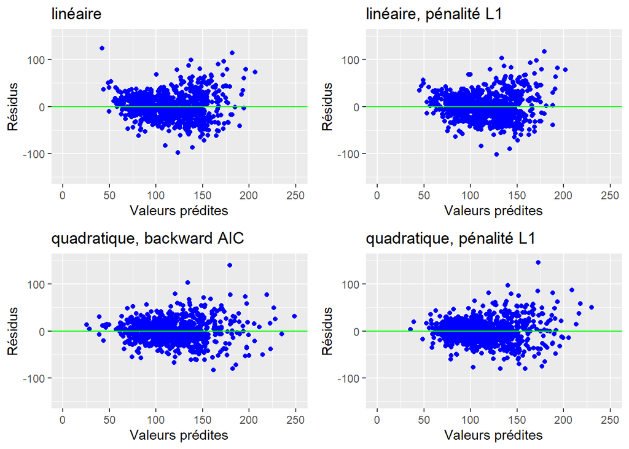

```r
# Extraction des valeurs ajustées et des résidus
fit.glm <- reg.glm.step$fitted.values
res.glm <- reg.glm.step$residuals
fit.lasso2 <- predict(reg.lasso2.cv, s = "lambda.min", newx = x.mat2)
res.lasso2 <- datappr$O3obs - fit.lasso2

# Graphe des résidus
g1<-gplot.res(fit.lm, res.lm, "linéaire")
g2<-gplot.res(fit.lasso, res.lasso, "linéaire, pénalité L1")
g3<-gplot.res(fit.glm, res.glm, "quadratique, backward AIC")
g4<-gplot.res(fit.lasso2, res.lasso2, "quadratique, pénalité L1")
grid.arrange(g1,g2,g3,g4,ncol=2,nrow=2)
```

On remarque que la présence de certaines interactions ou variables sont pertinentes au sens du critère d’Akaïke mais pas significative au sens du test de Fisher. Cette présence dans le modèle pourrait être plus finement analysée en considérant une estimation de l’erreur par validation croisée. L’idée serait de retirer une à une les variables ou interactions les moins significatives pour voir comment se comporte la validation croisée. D’autre part, si la procédure pas-à-pas conduit à un modèle différent, l’estimation de l’erreur par validation croisée permet également d’optimiser le choix.

Ces raffinements ne s’avèrent pas efficaces sur ces données. Le modèle obtenu par minimisaiton du critère AIC est conservé.

### Prévision de l’échantillon test

Le modèle “optimal” obtenu par la méthode descendante est utilisé pour prédire l’échantillon test et estimer ainsi, sans biais, une erreur de prévision. Deux erreurs sont estimées : la première est celle quadratique pour la régression tandis que la deuxième est issue de la matrice de confusion qui croise les dépassements de seuils prédits avec ceux effectivement observés.

#### Erreur de régression

```r
# Calcul des prévisions pour le modèle quadratique backward AIC
pred.glm <- predict(reg.glm.step, newdata = datestr)
# Erreur quadratique moyenne de prévision (MSE)
sum((pred.glm - datestr[, "O3obs"])^2) / nrow(datestr)
```

```
## [1] 601.5874
```

```r
# Erreur quadratique par MOCAGE
sum((datestr[,"MOCAGE"] - datestr[,"O3obs"])^2) / nrow(datestr)
```

```
## [1] 1384.503
```

#### Erreur de classification (matrice de confusion)

```r
# Matrice de confusion pour la prévision du dépassement de seuil
table(pred.glm > 150, datestr[, "O3obs"] > 150)
```

```
##
##         FALSE TRUE
##   FALSE   161   19
##   TRUE      5   24
```

```r
# Matrice de confusion pour la prévision du
# dépassement de seuil par MOCAGE
table(datestr[, "MOCAGE"] > 150, datestr[, "O3obs"] > 150)
```

```
##
##         FALSE TRUE
##   FALSE   141   19
##   TRUE     25   24
```

Noter ces erreurs pour les comparer avec celles obtenues par les autres méthodes. Noter l’asymétrie des erreurs.

## [Prévision par modèle binomial](http://wikistat.fr/pdf/st-m-app-rlogit.pdf)

Plutôt que de prévoir la concentration puis le dépassement, on peut se poser la question de savoir s’il ne serait pas pertinent de prévoir directement la présence ou l’absence d’un dépassement. La variable à modéliser étant binaire, c’est la régression logistique qui va être employée. Comme pour la régression, différentes stratégies de choix de modèle peuvent être utilisées et comparées avant d’estimer l’erreur de prévision sur l’échantillon test.

### Régression logistique sans interaction

```r
# estimation du modèle complet
log.lm <- glm(DepSeuil ~. , data = datappq, family = binomial)
# significativité des paramètres
anova(log.lm, test = "Chisq")
```

```
## Analysis of Deviance Table
##
## Model: binomial, link: logit
##
## Response: DepSeuil
##
## Terms added sequentially (first to last)
##
##
##         Df Deviance Resid. Df Resid. Dev  Pr(>Chi)
## NULL                      831     737.81
## JOUR     1    0.444       830     737.37 0.5050277
## MOCAGE   1  125.217       829     612.15 < 2.2e-16 ***
## TEMPE    1  136.842       828     475.31 < 2.2e-16 ***
## STATION  4   16.989       824     458.32 0.0019424 **
## VentMOD  1   11.786       823     446.54 0.0005968 ***
## VentANG  1    0.837       822     445.70 0.3601454
## SRMH2O   1    6.412       821     439.29 0.0113351 *
## LNO2     1    0.189       820     439.10 0.6634989
## LNO      1    5.378       819     433.72 0.0203939 *
## ---
## Signif. codes:  0 '***' 0.001 '**' 0.01 '*' 0.05 '.' 0.1 ' ' 1
```

```r
# Recherche d'un modèle optimal au sens d'Akaïke
log.lm.step <- step(log.lm, direction = "backward")
```

```
## Start:  AIC=459.72
## DepSeuil ~ JOUR + MOCAGE + TEMPE + STATION + VentMOD + VentANG +
##     SRMH2O + LNO2 + LNO
##
##           Df Deviance    AIC
## - MOCAGE   1   434.25 458.25
## - JOUR     1   434.36 458.36
## - VentANG  1   434.60 458.60
## <none>         433.72 459.72
## - LNO      1   439.10 463.10
## - LNO2     1   439.21 463.21
## - SRMH2O   1   440.49 464.49
## - VentMOD  1   440.90 464.90
## - STATION  4   455.47 473.47
## - TEMPE    1   550.99 574.99
##
## Step:  AIC=458.25
## DepSeuil ~ JOUR + TEMPE + STATION + VentMOD + VentANG + SRMH2O +
##     LNO2 + LNO
##
##           Df Deviance    AIC
## - JOUR     1   434.79 456.79
## - VentANG  1   435.23 457.23
## <none>         434.25 458.25
## - SRMH2O   1   441.49 463.49
## - VentMOD  1   442.86 464.86
## - LNO      1   447.00 469.00
## - LNO2     1   451.13 473.13
## - STATION  4   471.33 487.33
## - TEMPE    1   558.59 580.59
##
## Step:  AIC=456.79
## DepSeuil ~ TEMPE + STATION + VentMOD + VentANG + SRMH2O + LNO2 +
##     LNO
##
##           Df Deviance    AIC
## - VentANG  1   436.01 456.01
## <none>         434.79 456.79
## - SRMH2O   1   442.19 462.19
## - VentMOD  1   443.47 463.47
## - LNO      1   447.38 467.38
## - LNO2     1   451.41 471.41
## - STATION  4   472.00 486.00
## - TEMPE    1   559.99 579.99
##
## Step:  AIC=456.01
## DepSeuil ~ TEMPE + STATION + VentMOD + SRMH2O + LNO2 + LNO
##
##           Df Deviance    AIC
## <none>         436.01 456.01
## - SRMH2O   1   443.83 461.83
## - VentMOD  1   446.97 464.97
## - LNO      1   448.16 466.16
## - LNO2     1   452.55 470.55
## - STATION  4   475.30 487.30
## - TEMPE    1   565.19 583.19
```

```r
# Modèle obtenu
anova(log.lm.step, test = "Chisq")
```

```
## Analysis of Deviance Table
##
## Model: binomial, link: logit
##
## Response: DepSeuil
##
## Terms added sequentially (first to last)
##
##
##         Df Deviance Resid. Df Resid. Dev  Pr(>Chi)
## NULL                      831     737.81
## TEMPE    1  214.189       830     523.63 < 2.2e-16 ***
## STATION  4   32.316       826     491.31 1.649e-06 ***
## VentMOD  1   29.015       825     462.29 7.181e-08 ***
## SRMH2O   1    9.117       824     453.18 0.0025328 **
## LNO2     1    5.017       823     448.16 0.0250968 *
## LNO      1   12.151       822     436.01 0.0004907 ***
## ---
## Signif. codes:  0 '***' 0.001 '**' 0.01 '*' 0.05 '.' 0.1 ' ' 1
```

```r
# matrice de confusion de l'échantillon d'apprentissage et erreur apparente
table(log.lm.step$fitted.values > 0.5, datappq[, "DepSeuil"])
```

```
##
##         FALSE TRUE
##   FALSE   673   70
##   TRUE     24   65
```

### Régression logistique avec interactions

Avec autant de variables et d’interactions donc de paramètres, l’estimation du modèle complet de régression logistique rencontre des soucis et affiche des *warnings* car certaines probabilité trop bien ajustés (0 ou 1) provoquent des divisions par 0. Ici une procédure *forward* ou mieux *stepwise* de sélection des variables et interactions conduit à des résultats raisonnables. Une méthode avec pénalisation L1 peut aussi être utilisée.

```r
# régression avec le modèle minimum
log.qm <- glm(DepSeuil ~ 1, data = datappq,family = binomial)
# algorithme stepwise en précisant le plus grand
# modèle possible
log.qm.step1 <- step(log.qm, direction = "both",
    scope = list(lower = ~1, upper = ~(JOUR + MOCAGE + TEMPE +
            STATION + VentMOD + VentANG + LNO2 + LNO + SRMH2O)^2),
    family=binomial)
```

```
## Start:  AIC=739.81
## DepSeuil ~ 1
##
##           Df Deviance    AIC
## + TEMPE    1   523.63 527.63
## + MOCAGE   1   613.24 617.24
## + SRMH2O   1   683.87 687.87
## + VentANG  1   726.72 730.72
## + STATION  4   721.68 731.68
## + LNO2     1   727.76 731.76
## + VentMOD  1   733.38 737.38
## <none>         737.81 739.81
## + LNO      1   736.47 740.47
## + JOUR     1   737.37 741.37
##
## Step:  AIC=527.63
## DepSeuil ~ TEMPE
##
##           Df Deviance    AIC
## + MOCAGE   1   476.67 482.67
## + STATION  4   491.31 503.31
## + SRMH2O   1   503.12 509.12
## + VentMOD  1   515.31 521.31
## + VentANG  1   516.54 522.54
## <none>         523.63 527.63
## + LNO      1   521.92 527.92
## + JOUR     1   522.78 528.78
## + LNO2     1   523.06 529.06
## - TEMPE    1   737.81 739.81
##
## Step:  AIC=482.67
## DepSeuil ~ TEMPE + MOCAGE
##
##                Df Deviance    AIC
## + SRMH2O        1   465.50 473.50
## + STATION       4   460.11 474.11
## + LNO           1   470.23 478.23
## + LNO2          1   471.61 479.61
## + VentMOD       1   473.42 481.42
## + VentANG       1   473.55 481.55
```

[output cut: 204 more lines]

```
## <none>                 392.81 438.81
## + MOCAGE:TEMPE     1   390.84 438.84
## - MOCAGE:STATION   4   401.35 439.35
## + STATION:VentMOD  4   385.49 439.49
## + LNO              1   391.76 439.76
## + TEMPE:VentMOD    1   392.45 440.45
## + VentMOD:SRMH2O   1   392.59 440.59
## + LNO2             1   392.62 440.62
## + VentANG          1   392.75 440.75
## + JOUR             1   392.76 440.76
## + MOCAGE:SRMH2O    1   392.80 440.80
## - TEMPE:SRMH2O     1   399.88 443.88
## - MOCAGE:VentMOD   1   400.05 444.05
## - TEMPE:STATION    4   407.76 445.76
## - SRMH2O:STATION   4   415.01 453.01
```

```r
anova(log.qm.step1, test = "Chisq")
```

```
## Analysis of Deviance Table
##
## Model: binomial, link: logit
##
## Response: DepSeuil
##
## Terms added sequentially (first to last)
##
##
##                Df Deviance Resid. Df Resid. Dev  Pr(>Chi)
## NULL                             831     737.81
## TEMPE           1  214.189       830     523.63 < 2.2e-16 ***
## MOCAGE          1   46.956       829     476.67 7.258e-12 ***
## SRMH2O          1   11.172       828     465.50 0.0008302 ***
## STATION         4   15.922       824     449.57 0.0031252 **
## VentMOD         1    8.683       823     440.89 0.0032114 **
## TEMPE:STATION   4   11.682       819     429.21 0.0198767 *
## MOCAGE:VentMOD  1    5.702       818     423.51 0.0169449 *
## SRMH2O:STATION  4   15.219       814     408.29 0.0042684 **
## TEMPE:SRMH2O    1    6.941       813     401.35 0.0084241 **
## MOCAGE:STATION  4    8.537       809     392.81 0.0737674 .
## ---
## Signif. codes:  0 '***' 0.001 '**' 0.01 '*' 0.05 '.' 0.1 ' ' 1
```

### Prévision de l’échantillon test

#### Matrice de confusion

```r
# Prévision du modèle quadratique
pred.log <- predict(log.qm.step1, newdata = datestq, type = "response")
# Matrice de confusion pour la prévision du
# dépassement de seuil
table(pred.log > 0.5, datestq[, "DepSeuil"])
```

```
##
##         FALSE TRUE
##   FALSE   164   20
##   TRUE      2   23
```

Comparer avec l’approche précédente. Mémoriser les résultats obtenus pour comparer avec les autres méthodes.

#### Courbe ROC

Il est également possible de construire une courbe ROC en association de la prévision obtenue à partir d’un modèle gaussien. En effet, la variation du seuil théorique de dépassement (150) va faire varier les proportions respectives des taux de vrais et faux positifs. Cela revient encore à faire varier le seuil d’une “proba” pour les valeurs de prévisions divisées par 300.

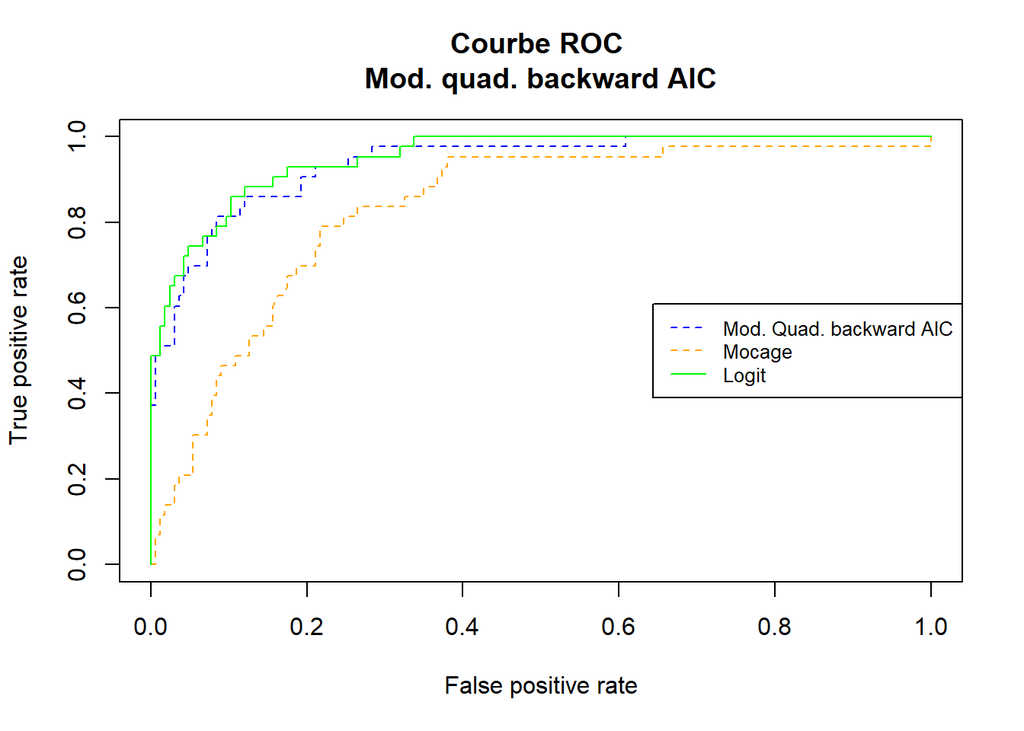

```r
options(repr.plot.width = 6, repr.plot.height = 6)
par(mfrow = c(1, 1))
rocmocage <- datestr[,  "MOCAGE"] / 300
DepSeuil=c(datestr[, "O3obs"] > 150)
predmocage <- prediction(rocmocage,DepSeuil)
perfmocage <- performance(predmocage, "tpr", "fpr")


rocglm <- pred.glm / 300
predglm <- prediction(rocglm,DepSeuil)
perfglm <- performance(predglm, "tpr", "fpr")

roclogit <- predict(log.qm.step1, newdata = datestq, type="response")
predlogit <- prediction(roclogit, datestq[, "DepSeuil"])
perflogit <- performance(predlogit, "tpr", "fpr")

plot(perfglm, col = "blue",lty=2, main = "Courbe ROC \n Mod. quad. backward AIC ")
plot(perfmocage,col="orange",lty=2,add=TRUE)
plot(perflogit,col="green",lty=1,add=TRUE)

legend("right", legend=c("Mod. Quad. backward AIC", "Mocage", "Logit"),
       col=c("blue","orange","green"), lty=c(2,2,1), text.font=1,    cex=0.8)
```

**Question** Que sont sensibilité et spécificité d’une courbe ROC?

**Réponse**

La sensibilité est la capacité à bien prédire les vrais positifs et la spécificité est la capacité a bien prédire les vrais négatifs.

Les résultats obtenus dépendent évidemment en plus de l’échantillonnage initial entre apprentissage et test. Dans le cas où les courbes se croisent, cela signifie qu’il n’y a pas de prévision uniformément meilleure de l’occurrence de dépassement. Cela dépend de la sensibilité ou de la spécificité retenue pour le modèle. Ceci souligne l’importance de la bonne définition du critère à utiliser pour le choix d’une “meilleure” méthode. Ce choix dépend directement de celui , “politique” ou “économique” de sensibilité et / ou spécificité du modèle retenu. En d’autres termes, quel taux de fausse alerte, avec des imputations économiques évidentes, est supportable au regard des dépassements non détectés et donc de la dégradation sanitaire de la population à risque ?

C’est une fois ce choix arrêté que le statisticien peut opérer une comparaison des méthodes en présence.

**Question** Les performances des deux approches gaussiennes et binomiales sont-elles très différentes ?

**Réponse**

Les courbes se croisent, ce qui suggère que la performance relative de ces modèles change avec le seuil de classification. À certains seuils, le modèle gaussien pourrait être préféré en raison d’une meilleure sensibilité, tandis qu’à d’autres, le modèle binomial pourrait être favorisé pour une meilleure spécificité.

Si il s’agit de predire une variable continue, un modèle gaussien serait approprié et plus performant. Tant dit que si l’on predit une variable binaire, l’approche binomiale (comme la régression logistique) serait plus adaptée.

**Question** Sur le graphe ci-dessus, ajouter la courbe ROC pour le modèle déterministe MOCAGE. Qu’observez-vous?

# Épisode 3 : CART, Agrégation de modèles

## [Arbre de décision binaire (CART)](http://wikistat.fr/pdf/st-m-app-cart.pdf)

La librairie `rpart` est celle la plus couramment utilisée pour la construction d’arbres de décision. Deux types d’arbres peuvent être estimés selon que la variable à modéliser est la concentration d’ozone (arbre de régression) ou directement le dépassement du seuil (arbre de discrimination ou de décision). Différents paramètres contrôlent l’exécution de l’algorithme : la pénalisation minimale (cp) pour la construction de l’arbre maximal, le nombre minimal d’observations par noeud, le nombre de validations croisées (par défaut 10)… cf. l’aide en ligne (`?rpart.control`) pour plus de détails mais celle-ci n’est pas très explicite sur certains paramètres.

NB. Une séquence de valeurs de la pénalisation `cp` est associée à une séquence d’arbres emboîtés.

### Estimation et élagage de l’arbre de régression

**Question** Quel critère est optimisé lors de la création d’un noeud de l’arbre?

**Réponse**

Dans un arbre de régression construit avec rpart, le critère optimisé lors de la création d’un nœud est la réduction de la somme des carrés des résidus, visant à minimiser l’erreur de prédiction.

```r
library(rpart)
help(rpart)
help(rpart.control)
```

```r
tree.reg=rpart(O3obs~.,data=datappr,control=rpart.control(cp=0.001))
```

La commande `summary(tree.reg)` fournit un descriptif de l’arbre obtenu mais un graphe est préférable.

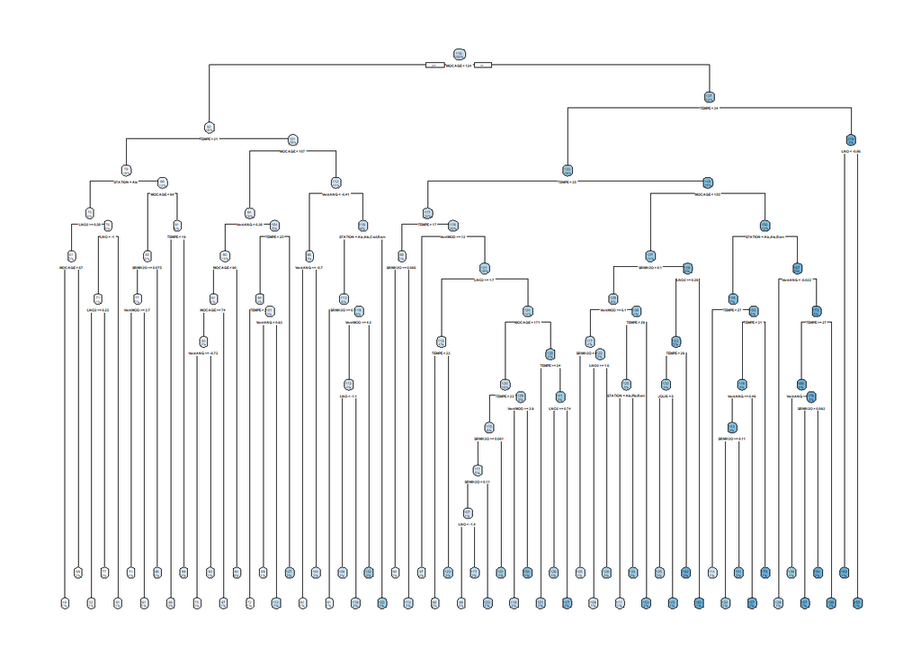

```r
library(rpart.plot)
options(repr.plot.width = 15, repr.plot.height = 10)
rpart.plot(tree.reg)
```

L’arbre est illisible et présente trop de feuilles pour une bonne prévision (sur-apprentissage), il est nécessaire d’en réduire le nombre par élagage. Les commandes suivantes calculent les prévisions obtenues par validation croisée 10-fold pour chaque arbre élagué suivant les valeurs successives du coefficient de complexité. La séquence de ces valeurs est implicitement celle fournit par `rpart`.

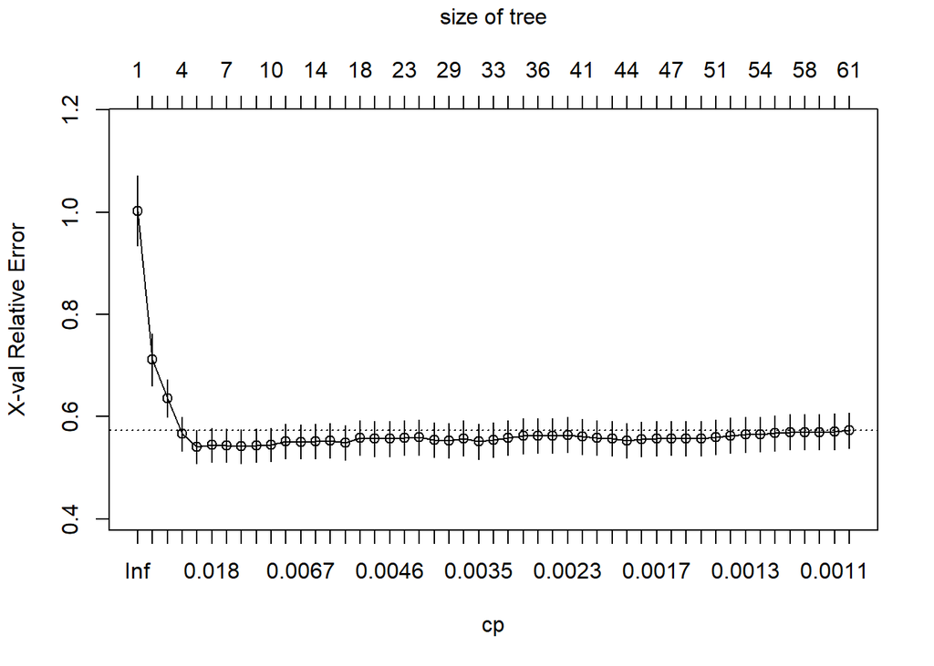

```r
help(xpred.rpart)
xmat<-xpred.rpart(tree.reg,xval=10)
# one row for each observation and one column for each complexity value

# Cross-validation error par valeur de CP
CVerr<-apply((xmat-datappr[,"O3obs"])^2,2,sum)

plotcp(tree.reg)
```

Cherchez la valeur de `cp` correspondant à la plus petite erreur puis utilisez la pour la construction de l’arbre.

```r
as.numeric(attributes(which.min(CVerr))$names)
```

```
## [1] 0.005972066
```

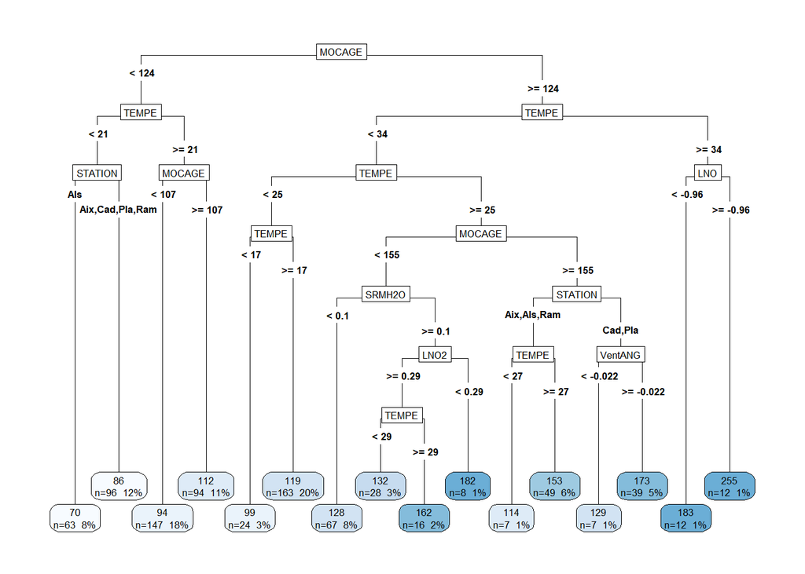

```r
tree.reg=rpart(O3obs~.,data=datappr,control=rpart.control(cp=as.numeric(attributes(which.min(CVerr))$names)))
rpart.plot(tree.reg,type=5,extra=101)
```

La librairie `partykit` propose une construction graphique de l’arbre:

```r
library(partykit)
```

[figure not shown]

```r
plot(as.party(tree.reg), type="simple")
```

La fenêtre est trop petite pour représenter les distributions (histogramme) de la variable cible (concentration en ozone) dans chaque feuille.

**Question** Quelle est la variable qui contribue le plus à l’interprétation ?

**Réponse**

MOCAGE est la variable qui contribue le plus a l’interprétation, de plus il est la variable principale pour diviser les données, sinon TEMPE si on ne compte pas la racine

Graphe des résidus

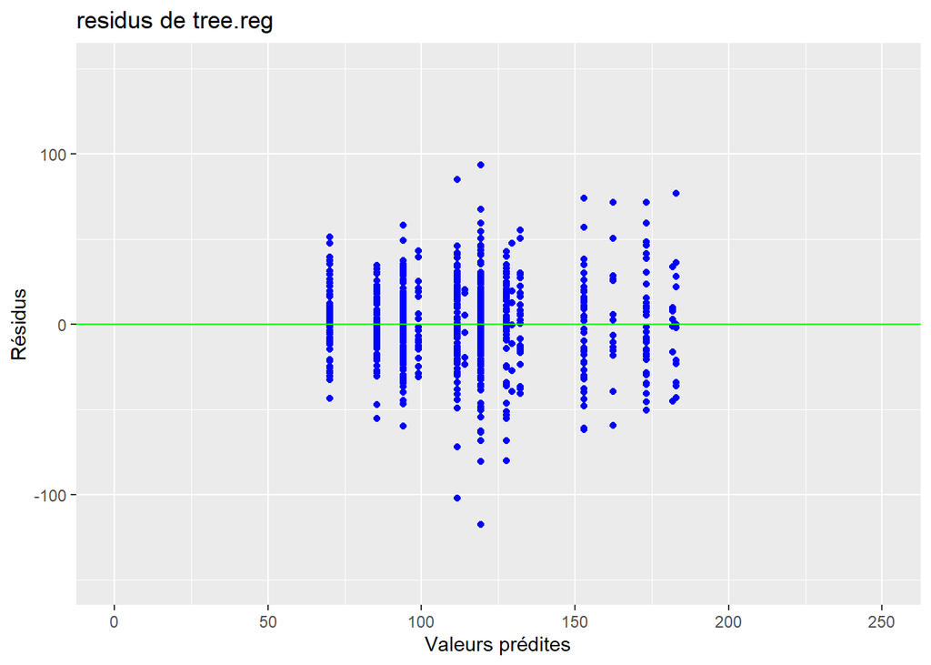

```r
fit.tree=predict(tree.reg)
res.tree=fit.tree-datappr[,"O3obs"]
gplot.res(fit.tree,res.tree,"residus de tree.reg")
```

**Question** A quoi est due la structure particulière de ce graphe ?

**Réponse**

La structure en bandes verticales du graphique des résidus est due à la nature des arbres de décision. Les arbres de décision fonctionnent en divisant l’espace des caractéristiques en régions homogènes.

Voici un exemple de code pour faire cet élagage avec la librairie `caret`

```r
library(caret)
ctrl <- trainControl(method = "cv",number = 10)
treecaret <- train(O3obs~.,data=datappr,method = "rpart",trControl = ctrl,tuneLength =20)
print(paste("Valeur de cp retenue = ",treecaret$bestTune,sep=""))
```

```
## [1] "Valeur de cp retenue = 0.00382648589685808"
```

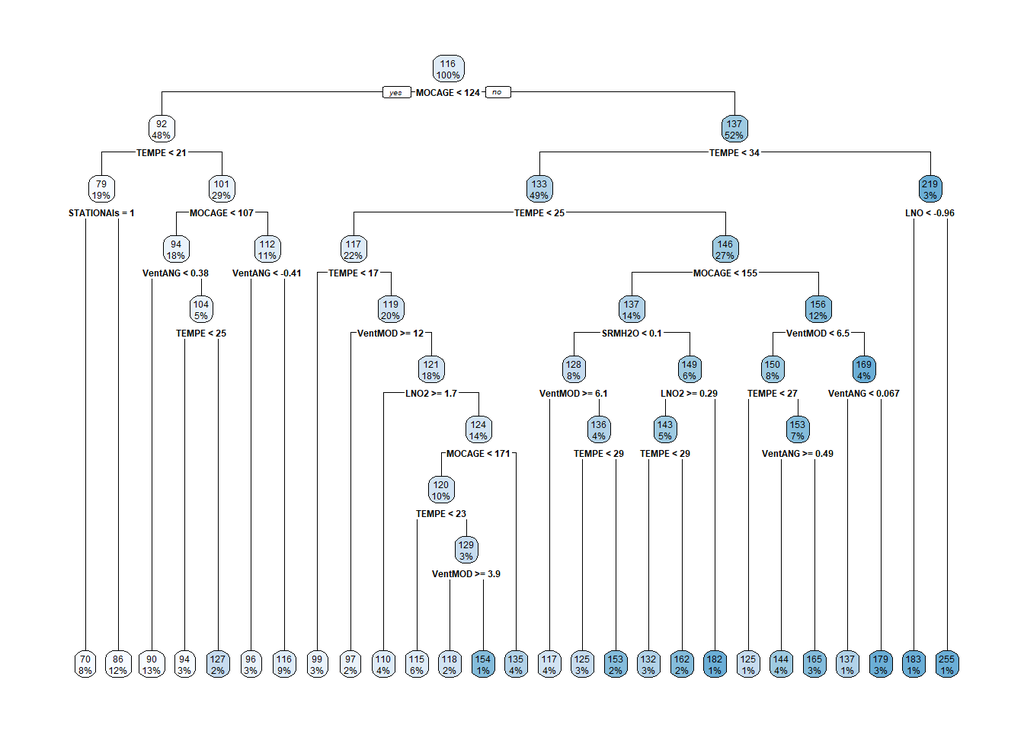

```r
rpart.plot(treecaret$finalModel)
```